# 1430_hands-on-part-1_FR

ATELIER PRATIQUE · INTELLIGENCE ARTIFICIELLE POUR LA STATISTIQUE PUBLIQUE

Un assistant RAG pour vos rapports PDF  
— l’édition complète

Documents multiples · mémoire de conversation · application web partageable · parcours débutant

🚀 Parcours express : 15 min 🔬 Parcours approfondi : 90 min 💻 Colab · Kaggle · local 🆓 Modèles gratuits intégrés

## 🎯 Ce que ce notebook réunit

📚

Plusieurs PDF à la fois

Une collection de documents, un filtre par document et des réponses qui combinent plusieurs rapports.

🧠

Mémoire de conversation

« Et pour les hommes ? » est comprise à partir de la question précédente, et la reformulation est affichée.

🌐

Application web partageable

Une interface Gradio avec import de PDF et un lien public, éventuellement protégé par mot de passe.

🚀

Parcours débutant

Trois cellules suffisent pour interroger vos documents sans lire une ligne de code.

Deux réglages décident de la qualité de tout le reste, et la partie B les mesure tous les deux sur vos propres documents : **`STRATEGIE_DECOUPAGE`** (cinq niveaux, du bloc de taille fixe à deux granularités avec tableaux et contexte) et **`RECLASSEMENT`** (quatre niveaux, d’aucun reclassement à un cross-encoder neuronal). La chaîne complète est dessinée après l’indexation, et `expliquer("votre question")` retrace n’importe quelle question à travers ses treize étapes.

Chaque réponse cite **le document, la section et la page**, affiche une **miniature de la page avec le passage surligné**, effectue des **vérifications automatiques** (chiffres, termes manquants), ou **refuse** de répondre lorsque l’information ne figure pas dans les documents.

## 🧭 Deux parcours, un seul notebook

|  | 🚀 **Parcours express** (débutants) | 🔬 **Parcours approfondi** |
| --- | --- | --- |
| **Pour qui** | Découvrir, faire une démonstration | Comprendre, adapter, évaluer |
| **Ce que vous faites** | *Exécution → Tout exécuter*, puis lire les parties **A** et **C** | Lire chaque partie, dans l’ordre |
| **Ce que vous modifiez** | La liste `DOCUMENTS` et, éventuellement, le modèle | Les réglages, le glossaire, les jeux de test |
| **Durée** | 15 minutes | 90 minutes |

### Plan

[output not shown]

| Repère | Signification |
| --- | --- |
| 💡 | **Point clé** |
| ⚠️ | **Piège** fréquent |
| 🧪 | **À vous** d’expérimenter |
| ⚙️ | **Cellule technique** — exécutez-la ; sa lecture est facultative |

Partie 0

0 · Mise en route

Installation, environnement, réglages et modèle de langage.

```python
# @title ⚙️ Installation des bibliothèques { display-mode: "form" }
import importlib, subprocess, sys

def installer(module, package):
    try:
        importlib.import_module(module)
    except ImportError:
        print(f"Installation de {package}…")
        subprocess.run([sys.executable, "-m", "pip", "install", "-q", package], check=False)

for module, package in [("numpy", "numpy"), ("pandas", "pandas"), ("sklearn", "scikit-learn"),
                        ("matplotlib", "matplotlib"), ("pymupdf", "pymupdf"), ("ipywidgets", "ipywidgets")]:
    installer(module, package)
print("✅ Bibliothèques prêtes.")
```

```
✅ Bibliothèques prêtes.
```

```python
# @title ⚙️ Mise en forme { display-mode: "form" }
import html as _html
import re, time, json, math, unicodedata
from collections import Counter
import numpy as np
import pandas as pd
import matplotlib.pyplot as plt
from IPython.display import HTML, display

C = dict(green="#00A86A", dark_green="#00704A", forest="#00553A", gold="#F5C242", ochre="#D49A00",
         teal="#0E7C86", terra="#C4621D", brick="#B83B2E", ink="#231F20", slate="#5E6964",
         mist="#F4F7F5", mint="#E8F5EF", sage="#D5DED9", grey="#A9B5B0")

_CSS = f"""<style>
.rg {{font-family:'Segoe UI',Calibri,system-ui,sans-serif;color:{C['ink']};}}
.rg-title {{font-weight:700;font-size:15px;margin:6px 0 6px 0;color:{C['ink']};}}
.rg-note {{font-size:12.5px;color:{C['slate']};font-style:italic;margin:6px 0 2px 0;}}
table.rg-t {{border-collapse:collapse;font-size:13px;width:100%;background:#fff;}}
table.rg-t th {{background:{C['forest']};color:#fff;padding:7px 10px;text-align:left;font-weight:600;}}
table.rg-t td {{padding:6px 10px;border-bottom:1px solid {C['sage']};color:{C['ink']};background:#fff;vertical-align:top;}}
table.rg-t tr:nth-child(even) td {{background:{C['mist']};}}
.rg-card {{background:#fff;border:1px solid {C['sage']};border-radius:12px;padding:14px 18px;margin:10px 0;color:{C['ink']};}}
.rg-pastille {{display:inline-block;border-radius:12px;padding:2px 10px;font-size:11.5px;font-weight:700;margin:0 6px 3px 0;}}
.rg-src {{font-size:12.5px;color:{C['slate']};border-top:1px dashed {C['sage']};padding-top:6px;margin-top:6px;}}
</style>"""

def pastille(text, color):
    return (f'<span class="rg-pastille" style="background:{color}22;color:{color};'
            f'border:1px solid {color};">{_html.escape(str(text))}</span>')

def tableau(df, title=None, note=None):
    body = df.to_html(index=False, escape=False, classes="rg-t", border=0)
    t = f'<div class="rg-title">{title}</div>' if title else ""
    n = f'<div class="rg-note">{note}</div>' if note else ""
    display(HTML(f'{_CSS}<div class="rg">{t}<div style="overflow-x:auto">{body}</div>{n}</div>'))

def encadre(text, kind="info"):
    styles = {"info": (C["teal"], "💡"), "success": (C["green"], "✅"),
              "warning": (C["ochre"], "⚠️"), "error": (C["brick"], "⛔")}
    color, icon = styles[kind]
    display(HTML(f'{_CSS}<div class="rg" style="background:{color}14;border:1px solid {color};'
                 f'border-radius:10px;padding:10px 16px;margin:8px 0;">{icon}&nbsp; {text}</div>'))

plt.rcParams.update({
    "figure.dpi": 110, "figure.facecolor": "white", "axes.facecolor": "white",
    "axes.spines.top": False, "axes.spines.right": False, "axes.edgecolor": C["sage"],
    "axes.labelcolor": C["slate"], "xtick.color": C["slate"], "ytick.color": C["slate"],
    "axes.titleweight": "bold", "axes.titlesize": 12.5, "axes.titlecolor": C["ink"],
    "font.size": 10, "legend.frameon": False,
})
encadre("Mise en forme prête.", "success")
```

✅ Mise en forme prête.

```python
# @title 🔎 Détection de l'environnement { display-mode: "form" }
import os, shutil, platform, urllib.request
from pathlib import Path

def detecter_environnement():
    if "google.colab" in sys.modules or os.environ.get("COLAB_RELEASE_TAG"):
        name = "colab"
    elif os.environ.get("KAGGLE_KERNEL_RUN_TYPE") or Path("/kaggle/working").exists():
        name = "kaggle"
    else:
        name = "local"
    gpu = None
    if shutil.which("nvidia-smi"):
        try:
            out = subprocess.run(["nvidia-smi", "--query-gpu=name", "--format=csv,noheader"],
                                 capture_output=True, text=True, timeout=10).stdout.strip()
            gpu = out.splitlines()[0] if out else None
        except Exception:
            gpu = None
    try:
        urllib.request.urlopen("https://pypi.org", timeout=4)
        internet = True
    except Exception:
        internet = False
    root = Path("/kaggle/working") if name == "kaggle" else Path.cwd()
    return {"name": name, "gpu": gpu, "internet": internet, "root": root,
            "system": f"{platform.system()} · Python {platform.python_version()}"}

ENV = detecter_environnement()

_LABELS = {"colab": ("Google Colab", "☁️"), "kaggle": ("Kaggle", "📊"), "local": ("votre ordinateur (local)", "💻")}
_INSTRUCTIONS = {
"colab": """
<li><b>Clé d'API gratuite (Groq)</b> : icône 🔑 <i>Secrets</i> dans la barre latérale gauche → ajoutez
<code>GROQ_API_KEY</code> et activez <i>Accès au notebook</i>.</li>
<li><b>Essais illimités (Ollama)</b> : <i>Exécution → Modifier le type d'exécution → GPU T4</i> <b>avant</b>
d'exécuter quoi que ce soit, puis <code>INSTALLER_OLLAMA = True</code> ci-dessous.</li>
<li><b>Vos PDF</b> : réglez <code>IMPORTER_PDF = True</code> (bouton d'import), ou ajoutez-les plus tard dans
l'<b>application web</b>.</li>
<li><b>Application web</b> : Gradio fournit un <b>lien public temporaire</b> à partager avec vos collègues.</li>
<li><b>⚠️ Vos fichiers sont effacés à la fin de la session.</b> La partie D télécharge une archive ZIP ;
vous pouvez aussi la copier sur Google Drive (<code>COPIER_SUR_DRIVE = True</code>).</li>""",
"kaggle": """
<li><b>Internet</b> : panneau de droite → <i>Settings → Internet : On</i>. Nécessaire pour Groq, Ollama et les installations.</li>
<li><b>Clé d'API gratuite (Groq)</b> : <i>Add-ons → Secrets</i> → ajoutez <code>GROQ_API_KEY</code> et attachez-la à ce notebook.</li>
<li><b>Essais illimités (Ollama)</b> : <i>Settings → Accelerator → GPU T4</i>, puis <code>INSTALLER_OLLAMA = True</code>.</li>
<li><b>Vos PDF</b> : <i>Add Input</i> → <i>Upload</i> ; les PDF de <code>/kaggle/input</code> sont listés à l'étape A1.
Copiez leur chemin (ou leur dossier) dans <code>DOCUMENTS</code>.</li>
<li><b>Application web</b> : l'accès passe par le <b>lien public</b> Gradio (Internet nécessaire).</li>
<li><b>Vos livrables</b> sont écrits dans <code>/kaggle/working</code> et conservés avec <i>Save Version</i> (onglet <i>Output</i>).</li>""",
"local": """
<li><b>Clé d'API gratuite (Groq)</b> : définissez la variable avant de lancer Jupyter —
<code>export GROQ_API_KEY=…</code> (macOS/Linux) ou <code>setx GROQ_API_KEY …</code> (Windows, puis rouvrez le terminal).</li>
<li><b>Essais illimités (Ollama)</b> : installez Ollama depuis <code>ollama.com/download</code>, puis dans un terminal :
<code>ollama pull qwen2.5:3b</code>. Le notebook le détecte automatiquement.</li>
<li><b>Vos PDF</b> : indiquez un fichier, un dossier ou une adresse web dans <code>DOCUMENTS</code>.</li>
<li><b>Application web</b> : Gradio s'ouvre dans votre navigateur sur <code>http://127.0.0.1:7860</code>.</li>
<li><b>Vos livrables</b> sont écrits sur votre disque, dans le dossier <code>sorties_rag</code>.</li>""",
}

label, icon = _LABELS[ENV["name"]]
state = lambda ok: ("✅", C["dark_green"]) if ok else ("⚠️", C["ochre"])
status_line = "".join(
    f'<span style="display:inline-block;margin:3px 14px 3px 0;"><b>{name}</b>: '
    f'<span style="color:{state(ok)[1]}">{state(ok)[0]} {value}</span></span>'
    for name, ok, value in [
        ("GPU", bool(ENV["gpu"]), ENV["gpu"] or "aucun (sans importance, sauf pour Ollama)"),
        ("Internet", ENV["internet"], "disponible" if ENV["internet"] else "indisponible"),
        ("Dossier de travail", True, str(ENV["root"])),
        ("Système", True, ENV["system"]),
    ])
display(HTML(
    f'{_CSS}<div class="rg" style="background:linear-gradient(120deg,{C["forest"]} 0%,{C["green"]} 100%);'
    f'border-radius:14px;padding:16px 22px;color:#fff;margin:8px 0 0 0;">'
    f'<div style="color:{C["gold"]};font-size:11.5px;font-weight:700;letter-spacing:2.5px;">ENVIRONNEMENT DÉTECTÉ</div>'
    f'<div style="font-size:24px;font-weight:800;margin:2px 0;">{icon} Vous êtes sur {label}</div></div>'
    f'<div class="rg rg-card" style="margin-top:0;border-radius:0 0 14px 14px;">'
    f'<div style="font-size:13px;margin-bottom:8px;">{status_line}</div>'
    f'<div class="rg-title">Marche à suivre dans cet environnement</div>'
    f'<ul style="margin:4px 0 0 0;padding-left:20px;line-height:1.65;font-size:13.5px;">{_INSTRUCTIONS[ENV["name"]]}</ul></div>'))
if not ENV["internet"]:
    encadre("Pas d'accès à Internet : le notebook fonctionnera en <b>mode extractif</b>, avec la recherche "
            "sémantique hors ligne. Sur Kaggle, activez Internet dans les réglages, puis redémarrez la session.", "warning")
```

ENVIRONNEMENT DÉTECTÉ

💻 Vous êtes sur votre ordinateur (local)

**GPU**: ⚠️ aucun (sans importance, sauf pour Ollama)**Internet**: ✅ disponible**Dossier de travail**: ✅ C:\Users\ASUS\Docs**Système**: ✅ Windows · Python 3.11.15

Marche à suivre dans cet environnement

- **Clé d'API gratuite (Groq)** : définissez la variable avant de lancer Jupyter — `export GROQ_API_KEY=…` (macOS/Linux) ou `setx GROQ_API_KEY …` (Windows, puis rouvrez le terminal).

- **Essais illimités (Ollama)** : installez Ollama depuis `ollama.com/download`, puis dans un terminal : `ollama pull qwen2.5:3b`. Le notebook le détecte automatiquement.

- **Vos PDF** : indiquez un fichier, un dossier ou une adresse web dans `DOCUMENTS`.

- **Application web** : Gradio s'ouvre dans votre navigateur sur `http://127.0.0.1:7860`.

- **Vos livrables** sont écrits sur votre disque, dans le dossier `sorties_rag`.

### 🎛️ Réglages

`LANGUE_DOCUMENTS` indique au moteur de recherche comment lire le texte : `"en"` pour des documents en anglais, `"fr"` pour des documents en français.

**Les longs rapports institutionnels** (50 à 200 pages) sont le cas normal dans un institut de statistique. Trois réglages comptent pour eux :

[output not shown]

> ⚠️ **Les adresses web ne fonctionnent pas toujours.** De nombreux portails institutionnels — `afdb.org` parmi eux — refusent les téléchargements qui ne proviennent pas d’un navigateur et répondent **HTTP 403**. Le notebook essaie des en-têtes imitant un navigateur, puis `curl`, et si les deux échouent il **ignore ce document et poursuit avec les autres**, en vous indiquant lequel a échoué.

> **Les liens de partage fonctionnent aussi.** Un lien Google Drive, Dropbox ou OneDrive est converti automatiquement en téléchargement direct, y compris l’avertissement antivirus de Drive pour les gros fichiers. Le fichier doit être partagé avec **« toute personne disposant du lien »** ; un lien privé renvoie une page web au lieu d’un PDF, et le notebook le signale.

```python
# ═══ 1. VOS DOCUMENTS ════════════════════════════════════════════════════════
DOCUMENTS = ["exemple"]                # "exemple", fichiers, dossiers ou adresses web
# Exemples prêts à l'emploi — de vrais rapports institutionnels :
# DOCUMENTS = ["https://au.int/sites/default/files/documents/44004-doc-FR_Strategie_Continentale_sur_lIntelligence_Artificielle_3.pdf"]
# DOCUMENTS = ["https://au.int/sites/default/files/documents/44004-doc-EN-_Continental_AI_Strategy_July_2024.pdf"]  # avec LANGUE_DOCUMENTS = "en"
# DOCUMENTS = ["https://www.afdb.org/sites/default/files/documents/publications/data_innovation_for_africa_-_a_practical_guide_to_applying_the_afdbs_data_innovation_maturity_model.pdf"]
#   ⚠️ afdb.org refuse souvent les téléchargements automatiques (HTTP 403). Deux solutions : importer le
#   fichier (IMPORTER_PDF = True), ou le déposer sur Google Drive et coller le lien de partage, qui est
#   converti automatiquement — le fichier doit être partagé avec « tous ceux qui ont le lien » :
# DOCUMENTS = ["https://drive.google.com/file/d/16HiHZEEO05fijl-ZX3CVP-ut3oa-0P0g/view?usp=drive_link"]
# DOCUMENTS = ["rapports/"]            # tous les PDF d'un dossier
LANGUE_DOCUMENTS = "fr"                # "fr" (français) ou "en" (anglais)
IMPORTER_PDF = False                   # Colab : affiche un bouton d'import pour vos PDF
UTILISER_OCR = False                   # lit les pages scannées (plus lent)
LANGUE_OCR = "fra"                     # "fra", "eng", "fra+eng"…

# ═══ 2. MODÈLE DE LANGAGE (facultatif) ═══════════════════════════════════════
FOURNISSEUR = "auto"                   # "auto", "ollama", "groq", "anthropic", "openai" ou "aucun"
DEMANDER_CLE = True                    # si aucun modèle n'est trouvé, s'arrête et demande une clé Groq (étape 0b)
INSTALLER_OLLAMA = False               # True : installe Ollama ici, essais illimités
MODELE_OLLAMA = "qwen2.5:3b"
MODELE_GROQ = "openai/gpt-oss-20b"
MODELE_ANTHROPIC = "claude-haiku-4-5-20251001"
MODELE_OPENAI = "gpt-4o-mini"

# ═══ 3. APPLICATION WEB (Gradio) ═════════════════════════════════════════════
LANCER_INTERFACE_WEB = True            # lance l'application web à l'étape C2
PARTAGER_LIEN = ENV["name"] in ("colab", "kaggle")   # lien public temporaire
MOT_DE_PASSE_WEB = ""                  # recommandé si vous partagez le lien, par exemple "atelier2026"
UTILISATEUR_WEB = "atelier"

# ═══ 4. RÉGLAGES AVANCÉS (parcours approfondi) ═══════════════════════════════
SUPPRIMER_ENTETES = True
EXTRAIRE_TABLEAUX = True
# ── Les deux choix qui décident de la qualité des réponses (la partie B les compare) ──
STRATEGIE_DECOUPAGE = "smart"          # "fixed" | "sentences" | "sections" | "hybrid" | "smart"
RECLASSEMENT = "smart"                 # "none" | "coverage" | "smart" | "cross-encoder"
MODELE_CROSS_ENCODER = "cross-encoder/ms-marco-MiniLM-L-6-v2"
FENETRE_PHRASES = 3                    # taille des petites fenêtres de recherche, en phrases
PAS_FENETRE = 2                        # pas entre deux fenêtres
TAILLE_MAX = 700                       # taille d'un passage de contexte (mesuré : meilleur que 1000 sur un long rapport)
TAILLE_MIN = 280                       # un passage plus court est fusionné avec le précédent
CHEVAUCHEMENT_PHRASES = 1              # phrases répétées entre deux passages d'une même section
CONTEXTE_VOISIN = True                 # joint les passages voisins de la section à la réponse
TAILLE_CONTEXTE = 1800                 # limite de taille de ce contexte élargi
K_RESULTATS = 4                        # passages transmis au modèle
UTILISER_EMBEDDINGS = True
INSTALLER_EMBEDDINGS = False           # True : installe sentence-transformers (recherche par le sens)
MODELE_EMBEDDINGS = "sentence-transformers/paraphrase-multilingual-MiniLM-L12-v2"
QUESTIONS_EVALUATION = []              # [("question", ["texte attendu"]), …] — utilisé par le banc d'essai (B3)
SEUIL_MANUEL = None                    # None = calibré automatiquement
MEMOIRE_PAR_MODELE = True              # le modèle réécrit les questions de suivi, s'il est disponible
UTILISER_CACHE = True                  # réutilise extraction et embeddings d'une exécution à l'autre
SUPPRIMER_SOMMAIRE = True              # écarte les lignes « Chapitre 3 …… 42 » et assimilées
MAX_PAGES_PAR_DOCUMENT = 0             # 0 = pas de limite ; 40 par exemple pour tester un très long rapport

# ═══ 5. LIVRABLES ════════════════════════════════════════════════════════════
DOSSIER_SORTIE = ENV["root"] / "sorties_rag"
DOSSIER_CACHE = ENV["root"] / "cache_rag"
TELECHARGER_LIVRABLES = True
COPIER_SUR_DRIVE = False

DOSSIER_SORTIE.mkdir(parents=True, exist_ok=True)
DOSSIER_CACHE.mkdir(parents=True, exist_ok=True)
print(f"Réglages chargés · environnement : {ENV['name']} · {len(DOCUMENTS)} source(s) · langue : {LANGUE_DOCUMENTS}")
```

```
Réglages chargés · environnement : local · 1 source(s) · langue : fr
```

Partie 0

0b · Le modèle de langage

Il rédige les réponses et comprend les questions de relance. Deux options gratuites sont intégrées.

Un modèle n’est **pas obligatoire** : sans lui, le notebook fonctionne en **mode extractif** (il recopie la phrase la plus pertinente des documents). Mais pour voir comment un RAG se comporte réellement — et surtout comment il **refuse** de répondre — il faut un modèle. Voici les options, de la mieux adaptée à un usage intensif à la moins adaptée :

| Option | Coût | Volume | Mise en place | Pour qui ? |
| --- | --- | --- | --- | --- |
| 🥇 **Ollama** (modèle ouvert exécuté sur la machine) | Gratuit | **Illimité** | 3 à 5 min (installation + téléchargement d’environ 2 Go) | Ateliers, pratique intensive, documents sensibles |
| 🥈 **Groq** (API) | Gratuit, sans carte bancaire | **1 000 requêtes/jour par modèle**, 30/min, 8 000 tokens/min | 1 min (clé sur `console.groq.com/keys`) | Démarrage rapide, réponses très rapides |
| Anthropic, OpenAI (API) | Payant | Selon le budget | 1 min | Comparaison avec des modèles commerciaux |

**Ordre de grandeur.** Un parcours complet de ce notebook demande environ **30 appels au modèle** : avec Groq, une trentaine de parcours par jour et par modèle ; avec Ollama, aucune limite.

> ⚠️ **Quotas.** Les limites de Groq indiquées ci-dessus sont celles de sa documentation officielle en septembre 2026. Elles évoluent : consultez `console.groq.com/settings/limits` pour connaître les valeurs de votre compte. Lorsqu’une limite est atteinte, le notebook **attend automatiquement** le délai demandé par le service, puis réessaie.

> 💡 **Ollama et confidentialité.** Avec Ollama, aucun texte ne quitte la machine. C’est l’option à préférer dès que la collection comporte des documents non publiés.

> 💡 **Ollama sur Colab ou Kaggle.** Activez un **GPU T4 avant d’exécuter le notebook**. Ollama détecte le GPU et y charge le modèle automatiquement ; `qwen2.5:3b` occupe environ 3 Go des 16 Go de la T4.

⚠️ **Ne collez jamais une clé d’API directement dans une cellule.** Utilisez les secrets de Colab ou de Kaggle, ou une variable d’environnement en local.

```python
# @title 🦙 Installation d'Ollama (si demandée) { display-mode: "form" }
def _ollama_running():
    try:
        urllib.request.urlopen("http://localhost:11434/api/tags", timeout=2)
        return True
    except Exception:
        return False

def installer_ollama(model):
    if _ollama_running():
        print("Ollama tourne déjà.")
    elif platform.system() != "Linux":
        encadre("L'installation automatique n'est disponible que sur Linux (Colab, Kaggle). Sur macOS ou Windows, "
                "installez Ollama depuis <code>ollama.com/download</code>, puis réexécutez cette cellule.", "warning")
        return False
    else:
        if not shutil.which("ollama"):
            print("1/3 · Installation d'Ollama (1 à 2 min)…")
            if shutil.which("apt-get"):
                subprocess.run("apt-get install -y -qq zstd pciutils > /dev/null 2>&1 || "
                               "(apt-get update -qq > /dev/null 2>&1 && apt-get install -y -qq zstd pciutils > /dev/null 2>&1)",
                               shell=True)
            subprocess.run("curl -fsSL https://ollama.com/install.sh | sh > ollama_install.log 2>&1", shell=True)
        if not shutil.which("ollama"):
            encadre("L'installation a échoué : voir le fichier <code>ollama_install.log</code>.", "error")
            return False
        print("2/3 · Démarrage du service…")
        subprocess.Popen(["ollama", "serve"], stdout=subprocess.DEVNULL, stderr=subprocess.DEVNULL,
                         start_new_session=True)
        for _ in range(30):
            if _ollama_running():
                break
            time.sleep(1)
    print(f"3/3 · Téléchargement du modèle {model} (quelques minutes la première fois)…")
    result = subprocess.run(["ollama", "pull", model], capture_output=True, text=True)
    if result.returncode != 0:
        encadre(f"Téléchargement du modèle impossible : <code>{_html.escape(result.stderr[-300:])}</code>", "error")
        return False
    encadre(f"Ollama est prêt avec le modèle <b>{model}</b> · essais illimités."
            + ("" if ENV["gpu"] else " <br>⚠️ Sans GPU, chaque réponse peut demander de 10 à 60 secondes."), "success")
    return True

if INSTALLER_OLLAMA:
    installer_ollama(MODELE_OLLAMA)
else:
    print("Installation d'Ollama non demandée (INSTALLER_OLLAMA = False).")
```

```
Installation d'Ollama non demandée (INSTALLER_OLLAMA = False).
```

```python
# @title 🤖 Connexion au modèle { display-mode: "form" }
import urllib.error

def _secret(name):
    value = os.environ.get(name)
    if value:
        return value
    if ENV["name"] == "colab":
        try:
            from google.colab import userdata
            return userdata.get(name)
        except Exception:
            return None
    if ENV["name"] == "kaggle":
        try:
            from kaggle_secrets import UserSecretsClient
            return UserSecretsClient().get_secret(name)
        except Exception:
            return None
    return None

def _poster(url, payload, headers, timeout=120):
    request = urllib.request.Request(url, data=json.dumps(payload).encode("utf-8"),
                                     headers={"Content-Type": "application/json", **headers})
    with urllib.request.urlopen(request, timeout=timeout) as response:
        return json.loads(response.read().decode("utf-8"))

class ClientLLM:
    """Une seule interface pour Ollama, Groq, Anthropic ou OpenAI.
    Température 0, respect des quotas : pause entre les appels, nouvel essai après un HTTP 429."""

    MIN_PAUSE = {"groq": 2.2, "anthropic": 0.5, "openai": 0.5, "ollama": 0.0}

    def __init__(self, choice="auto"):
        self.found = {"ollama": _ollama_running(),
                      "groq": bool(_secret("GROQ_API_KEY")),
                      "anthropic": bool(_secret("ANTHROPIC_API_KEY")),
                      "openai": bool(_secret("OPENAI_API_KEY"))}
        order = ["ollama", "groq", "anthropic", "openai"] if choice == "auto" else [choice]
        self.name = next((p for p in order if self.found.get(p)), "none")
        self.model = {"ollama": MODELE_OLLAMA, "groq": MODELE_GROQ, "anthropic": MODELE_ANTHROPIC,
                      "openai": MODELE_OPENAI}.get(self.name, "—")
        self.calls, self.waited, self._last = 0, 0.0, 0.0

    @property
    def available(self):
        return self.name != "none"

    def _call(self, system, message, max_tokens):
        if self.name == "ollama":
            d = _poster("http://localhost:11434/api/chat",
                      {"model": self.model, "stream": False, "options": {"temperature": 0},
                       "messages": [{"role": "system", "content": system},
                                    {"role": "user", "content": message}]}, {}, timeout=600)
            return d["message"]["content"]
        if self.name == "groq":
            payload = {"model": self.model, "temperature": 0, "max_completion_tokens": max_tokens + 600,
                       "messages": [{"role": "system", "content": system},
                                    {"role": "user", "content": message}]}
            if "gpt-oss" in self.model:
                payload["reasoning_effort"] = "low"          # raisonnement court : moins de tokens consommés
            d = _poster("https://api.groq.com/openai/v1/chat/completions", payload,
                      {"Authorization": f"Bearer {_secret('GROQ_API_KEY')}"})
            return d["choices"][0]["message"].get("content") or ""
        if self.name == "anthropic":
            d = _poster("https://api.anthropic.com/v1/messages",
                      {"model": self.model, "max_tokens": max_tokens, "temperature": 0,
                       "system": system, "messages": [{"role": "user", "content": message}]},
                      {"x-api-key": _secret("ANTHROPIC_API_KEY"), "anthropic-version": "2023-06-01"})
            return "".join(b.get("text", "") for b in d["content"])
        if self.name == "openai":
            d = _poster("https://api.openai.com/v1/chat/completions",
                      {"model": self.model, "temperature": 0, "max_completion_tokens": max_tokens,
                       "messages": [{"role": "system", "content": system},
                                    {"role": "user", "content": message}]},
                      {"Authorization": f"Bearer {_secret('OPENAI_API_KEY')}"})
            return d["choices"][0]["message"]["content"]
        raise RuntimeError("Aucun fournisseur de modèle disponible.")

    def generate(self, system, message, max_tokens=400, attempts=5):
        for attempt in range(attempts):
            wait = self.MIN_PAUSE.get(self.name, 0) - (time.time() - self._last)
            if wait > 0:
                time.sleep(wait)
            try:
                self._last = time.time()
                text = self._call(system, message, max_tokens)
                self.calls += 1
                return re.sub(r"<think>.*?</think>", "", text, flags=re.S).strip()
            except urllib.error.HTTPError as error:
                if error.code == 429 and attempt < attempts - 1:
                    delay = min(float(error.headers.get("retry-after") or 2 ** (attempt + 2)), 90)
                    print(f"⏳ Quota momentanément atteint ({self.name}) : nouvel essai dans {delay:.0f} s…")
                    self.waited += delay
                    time.sleep(delay)
                    continue
                detail = error.read().decode("utf-8", "ignore")[:200]
                raise RuntimeError(f"HTTP {error.code}: {detail}") from error

# ── D'où vient chaque clé, et à quoi elle ressemble ────────────────────────────────────────
CLES_API = {"groq":      ("GROQ_API_KEY",      "gsk_",    "console.groq.com/keys (gratuit, sans carte bancaire)"),
            "anthropic": ("ANTHROPIC_API_KEY", "sk-ant-", "console.anthropic.com"),
            "openai":    ("OPENAI_API_KEY",    "sk-",     "platform.openai.com/api-keys")}

def demander_cle_api(provider):
    """Demande la clé du fournisseur, saisie masquée. Entrée seule passe l'étape.
    La clé reste en mémoire pour cette session : elle n'est jamais écrite dans le notebook."""
    variable, prefix, where = CLES_API[provider]
    import getpass
    try:
        key = getpass.getpass(f"🔑 Clé {provider.capitalize()} ({prefix}…) — à créer sur {where} — "
                              f"Entrée seule pour passer : ").strip()
    except Exception:
        return None                                  # exécution automatisée (nbconvert) : on passe
    if not key:
        encadre("Étape passée : l'assistant <b>recopiera</b> des phrases au lieu de rédiger les réponses. "
                "Vous pourrez coller une clé plus tard, dans la cellule suivante.", "info")
        return None
    if not key.startswith(prefix):
        encadre(f"Une clé {provider.capitalize()} commence par <code>{prefix}</code> — rien n'a été enregistré.", "error")
        return None
    os.environ[variable] = key
    return ClientLLM(provider)

LLM = ClientLLM("none" if FOURNISSEUR == "none" else FOURNISSEUR)

tableau(pd.DataFrame([
    {"Fournisseur": "Ollama (local)", "Coût": "gratuit · illimité", "Détecté": "✅" if LLM.found["ollama"] else "—",
     "Comment l'activer": "INSTALLER_OLLAMA = True, ou Ollama installé en local"},
    {"Fournisseur": "Groq", "Coût": "gratuit · 1 000 req./jour", "Détecté": "✅" if LLM.found["groq"] else "—",
     "Comment l'activer": "secret ou variable GROQ_API_KEY"},
    {"Fournisseur": "Anthropic", "Coût": "payant", "Détecté": "✅" if LLM.found["anthropic"] else "—",
     "Comment l'activer": "secret ou variable ANTHROPIC_API_KEY"},
    {"Fournisseur": "OpenAI", "Coût": "payant", "Détecté": "✅" if LLM.found["openai"] else "—",
     "Comment l'activer": "secret ou variable OPENAI_API_KEY"},
]), title="Fournisseurs de modèle détectés")

# ── Un fournisseur est demandé mais aucune clé n'est visible : on la demande, saisie masquée ────
if not LLM.available and FOURNISSEUR != "none" and DEMANDER_CLE:
    wanted = FOURNISSEUR if FOURNISSEUR in CLES_API else "groq"
    encadre(f"<b>{wanted.capitalize()}</b> est demandé, mais aucune clé n'a été trouvée dans les secrets ni dans "
            f"l'environnement. Collez-la ci-dessous : la saisie est masquée et la clé n'est jamais écrite dans "
            f"le notebook.", "warning")
    LLM = demander_cle_api(wanted) or LLM

if LLM.available:
    try:
        start = time.time()
        test = LLM.generate("Tu réponds par un seul mot.", "Réponds seulement : OK", max_tokens=20)
        encadre(f"Fournisseur retenu : <b>{LLM.name}</b> · modèle <code>{LLM.model}</code> · "
                f"test de connexion réussi en {time.time() - start:.1f} s (réponse : « {_html.escape(test[:30])} »).", "success")
    except Exception as error:
        encadre(f"Le fournisseur <b>{LLM.name}</b> a été détecté mais le test a échoué : "
                f"<code>{_html.escape(str(error)[:220])}</code><br>Le notebook bascule en <b>mode extractif</b>. "
                "Vérifiez la clé, le nom du modèle et l'accès à Internet.", "error")
        LLM.name, LLM.model = "none", "—"
else:
    encadre("Aucun modèle connecté : le notebook fonctionne en <b>mode extractif</b> — toutes les étapes "
            "fonctionnent, mais les réponses sont <b>recopiées</b> des documents au lieu d'être rédigées, et "
            "l'assistant ne sait ni compter, ni comparer, ni synthétiser. La cellule suivante permet de coller "
            "une clé à tout moment.", "warning")
```

Fournisseurs de modèle détectés

| Fournisseur | Coût | Détecté | Comment l'activer |
| --- | --- | --- | --- |
| Ollama (local) | gratuit · illimité | — | INSTALLER_OLLAMA = True, ou Ollama installé en local |
| Groq | gratuit · 1 000 req./jour | — | secret ou variable GROQ_API_KEY |
| Anthropic | payant | — | secret ou variable ANTHROPIC_API_KEY |
| OpenAI | payant | — | secret ou variable OPENAI_API_KEY |

⚠️ **Groq** est demandé, mais aucune clé n'a été trouvée dans les secrets ni dans l'environnement. Collez-la ci-dessous : la saisie est masquée et la clé n'est jamais écrite dans le notebook.

⛔ Le fournisseur **groq** a été détecté mais le test a échoué : `HTTP 403: error code: 1010`  
Le notebook bascule en **mode extractif**. Vérifiez la clé, le nom du modèle et l'accès à Internet.

### 🔑 Étape 0b — Vos clés (Groq, Hugging Face)

Le panneau ci-dessous est **toujours affiché**, quel que soit ce qui a été détecté plus haut. Il accepte deux clés, toutes deux facultatives :

| Clé | À quoi elle sert | Nécessaire ? |
| --- | --- | --- |
| **Groq** (`gsk_…`) | Le modèle qui **rédige** les réponses à partir des sources | Seulement si vous voulez des réponses rédigées plutôt que des phrases recopiées, et qu’aucun Ollama ne tourne |
| **Hugging Face** (`hf_…`) | Le téléchargement du modèle de recherche sémantique | **Pas nécessaire** pour le modèle par défaut, qui est public. Utile pour un modèle privé ou à accès restreint, ou lorsque les téléchargements anonymes sont limités en débit sur Colab |

### Obtenir une clé Groq gratuite (2 minutes)

Sans modèle, l’assistant recopie des phrases ; avec un modèle, il **rédige** la réponse à partir des sources. Groq est le moyen le plus rapide d’y parvenir gratuitement :

1. Ouvrez **`console.groq.com/keys`** et connectez-vous (compte Google ou GitHub, sans carte bancaire).
2. Cliquez sur **Create API Key**, donnez-lui un nom et copiez la clé (`gsk_…`) — elle n’est affichée qu’une seule fois.
3. Conservez-la, par ordre de préférence :
   - **Colab** : 🔑 *Secrets* dans la barre latérale gauche → nom `GROQ_API_KEY`, collez la valeur, activez *Accès au notebook*, puis réexécutez les cellules ci-dessus.
   - **Kaggle** : *Add-ons → Secrets* → même nom, rattachez-le au notebook.
   - **En local** : `exporter GROQ_API_KEY=gsk_…` avant de démarrer Jupyter.
   - **Ou collez-la dans le champ ci-dessous** pour cette session uniquement.

Un jeton Hugging Face se crée de la même façon, sur **`huggingface.co/settings/tokens`** (un jeton *Read* suffit), et peut être conservé sous le nom `HF_TOKEN`.

> ⚠️ Les champs ci-dessous conservent les clés **en mémoire pour cette session uniquement**. Elles ne sont jamais écrites dans le notebook et disparaissent à la fin de la session. Ne tapez jamais une clé dans une cellule de code : les notebooks se partagent et s’archivent.

> 💡 **Pas de widgets dans votre éditeur ?** Utilisez plutôt les fonctions : `definir_cle_groq("gsk_…")` et `definir_jeton_hf("hf_…")`.

```python
# 🔑 Connectez vos clés pour cette session (Groq pour rédiger les réponses, Hugging Face pour le modèle de recherche).
import ipywidgets as widgets

def definir_cle_groq(key):
    """Utilise une clé Groq pour cette session (enregistrée nulle part)."""
    global LLM
    key = (key or "").strip()
    if not key.startswith("gsk_"):
        return "⛔ Une clé Groq commence par gsk_."
    os.environ["GROQ_API_KEY"] = key
    candidate = ClientLLM("groq")
    try:
        candidate.generate("Tu réponds par un seul mot.", "Réponds seulement : OK", max_tokens=20)
    except Exception as error:
        os.environ.pop("GROQ_API_KEY", None)
        return f"⛔ Clé refusée : {str(error)[:160]}"
    LLM = candidate
    return f"✅ Connecté à Groq · modèle {LLM.model}. Les réponses sont désormais rédigées — reposez votre question."

def definir_jeton_hf(token):
    """Utilise un jeton Hugging Face pour cette session (modèle privé ou restreint, limites de téléchargement)."""
    token = (token or "").strip()
    if not token.startswith("hf_"):
        return "⛔ Un jeton Hugging Face commence par hf_."
    os.environ["HF_TOKEN"] = os.environ["HUGGING_FACE_HUB_TOKEN"] = token
    try:
        from huggingface_hub import whoami
        return f"✅ Hugging Face connecté en tant que {whoami(token=token).get('name', 'utilisateur')}."
    except ImportError:
        return "✅ Jeton Hugging Face enregistré pour cette session."
    except Exception as error:
        os.environ.pop("HF_TOKEN", None); os.environ.pop("HUGGING_FACE_HUB_TOKEN", None)
        return f"⛔ Jeton refusé : {str(error)[:160]}"

def panneau_cles():
    groq_field = widgets.Password(placeholder="gsk_…", description="Clé Groq", layout=widgets.Layout(width="420px"))
    hf_field = widgets.Password(placeholder="hf_… (facultatif)", description="Jeton HF", layout=widgets.Layout(width="420px"))
    groq_button = widgets.Button(description="Connecter Groq", button_style="success", icon="key")
    hf_button = widgets.Button(description="Connecter HF", icon="key")
    message = widgets.HTML()

    def say(text):
        colour = C["dark_green"] if text.startswith("✅") else C["brick"]
        message.value = f'<span style="color:{colour};">{_html.escape(text)}</span>'

    def connect_groq(_=None):
        value, groq_field.value = groq_field.value, ""
        say(definir_cle_groq(value))

    def connect_hf(_=None):
        value, hf_field.value = hf_field.value, ""
        say(definir_jeton_hf(value))

    import warnings
    groq_button.on_click(connect_groq); hf_button.on_click(connect_hf)
    with warnings.catch_warnings():
        warnings.simplefilter("ignore")
        groq_field.on_submit(connect_groq); hf_field.on_submit(connect_hf)
    display(widgets.VBox([widgets.HBox([groq_field, groq_button]),
                          widgets.HBox([hf_field, hf_button]), message]))

if LLM.available:
    encadre(f"Un modèle est déjà connecté : <b>{LLM.name}</b> · <code>{LLM.model}</code>. "
            "Vous pouvez en changer en collant une autre clé ci-dessous.", "success")
else:
    display(HTML(f'{_CSS}<div class="rg" style="background:{C["gold"]}22;border:2px solid {C["gold"]};'
                 f'border-radius:12px;padding:14px 20px;"><div style="font-size:17px;font-weight:800;">'
                 f'🔑 Une clé Groq gratuite est nécessaire pour que les réponses soient <u>rédigées</u></div>'
                 f'<div style="font-size:13.5px;color:{C["slate"]};margin-top:4px;">Créez-en une en deux minutes sur '
                 f'<b>console.groq.com/keys</b> (sans carte bancaire). Sans elle, l&rsquo;assistant fonctionne mais '
                 f'<b>recopie</b> des phrases au lieu de rédiger — sans savoir compter, comparer ni synthétiser.'
                 f'</div></div>'))
panneau_cles()
```

🔑 Une clé Groq gratuite est nécessaire pour que les réponses soient rédigées

Créez-en une en deux minutes sur **console.groq.com/keys** (sans carte bancaire). Sans elle, l’assistant fonctionne mais **recopie** des phrases au lieu de rédiger — sans savoir compter, comparer ni synthétiser.

```
VBox(children=(HBox(children=(Password(description='Clé Groq', layout=Layout(width='420px'), placeholder='gsk_…
```

BOÎTE À OUTILS

⚙️ La boîte à outils

Cellules techniques. Parcours express : exécutez-les sans les lire. Sur Colab, elles sont repliées.

Six cellules définissent tout ce dont les deux parcours et les interfaces ont besoin. Le parcours approfondi (partie B) explique chaque brique et en montre l’effet.

| Cellule | Rôle |
| --- | --- |
| T1 | Rapports d’exemple et miniatures de pages |
| T2 | Diagnostic et extraction structurée (titres, en-têtes et pieds de page, tableaux, OCR) |
| T3 | Découpage en passages |
| T4 | Recherche : normalisation, glossaire, BM25, recherche sémantique, fusion, reclassement, filtre par document |
| T5 | Mémoire de conversation |
| T6 | La bibliothèque : chargement, indexation, calibrage, réponses, vérifications et avis |

```python
# @title ⚙️ T1 · Rapports d'exemple et vignettes { display-mode: "form" }
import io, base64, contextlib
import pymupdf

_RAPPORT_HTML = """
<h1>Rapport annuel sur le marché du travail 2025</h1>
<p class="warn">DONNÉES FICTIVES — document de formation. Aucun chiffre de ce rapport n'est réel.</p>
<h2>1. Avant-propos</h2>
<p>Ce rapport présente les principaux résultats de l'Enquête emploi continue (EEC) conduite en 2025 par l'Institut national de la statistique. Il couvre la population âgée de 15 ans et plus vivant dans les ménages ordinaires. Les estimations trimestrielles sont corrigées des variations saisonnières.</p>
<h2>2. Faits saillants</h2>
<ul>
<li>Le taux de chômage annuel moyen s'établit à 7,9 % en 2025, contre 8,4 % en 2024.</li>
<li>Le taux d'activité atteint 61,2 % en moyenne annuelle.</li>
<li>La part de l'emploi informel dans l'emploi total est estimée à 71,5 %.</li>
<li>Le chômage des jeunes de 15 à 24 ans reste élevé, à 17,6 %.</li>
</ul>
<h2>3. Population en âge de travailler</h2>
<p>En 2025, la population en âge de travailler compte 11,2 millions de personnes. Les femmes en représentent 50,8 %. La population active est estimée à 6,85 millions de personnes, dont 6,31 millions d'actifs occupés et 0,54 million de chômeurs.</p>
<p>La population en âge de travailler croît de 2,7 % par an, plus vite que l'emploi, ce qui maintient une pression continue sur le marché du travail.</p>
<h2>4. Activité et emploi</h2>
<p>Le tableau 1 présente l'évolution trimestrielle des principaux indicateurs. Le taux d'emploi progresse de 0,9 point entre le premier et le quatrième trimestre.</p>
<p><b>Tableau 1 — Indicateurs trimestriels du marché du travail en 2025 (%)</b></p>
<table>
<tr><th>Indicateur</th><th>T1</th><th>T2</th><th>T3</th><th>T4</th></tr>
<tr><td>Taux d'activité</td><td>60,9</td><td>61,5</td><td>61,1</td><td>61,3</td></tr>
<tr><td>Taux d'emploi</td><td>55,8</td><td>56,7</td><td>56,4</td><td>56,7</td></tr>
<tr><td>Taux de chômage</td><td>8,3</td><td>7,8</td><td>7,7</td><td>7,6</td></tr>
<tr><td>Sous-emploi lié à la durée du travail</td><td>12,9</td><td>12,4</td><td>12,2</td><td>12,0</td></tr>
</table>
<p>Source : Institut national de la statistique, EEC 2025 (données fictives).</p>
<h2>5. Chômage</h2>
<p>Le chômage touche davantage les femmes (9,3 %) que les hommes (6,7 %). Il est plus élevé en milieu urbain (10,4 %) qu'en milieu rural (5,2 %). Le tableau 2 détaille le taux de chômage par région.</p>
<p><b>Tableau 2 — Taux de chômage par région en 2025 (%)</b></p>
<table>
<tr><th>Région</th><th>Hommes</th><th>Femmes</th><th>Ensemble</th></tr>
<tr><td>Littoral</td><td>8,1</td><td>11,2</td><td>9,6</td></tr>
<tr><td>Centre</td><td>6,4</td><td>8,9</td><td>7,6</td></tr>
<tr><td>Nord</td><td>5,9</td><td>8,0</td><td>6,9</td></tr>
<tr><td>Sud</td><td>6,2</td><td>8,7</td><td>7,4</td></tr>
</table>
<p>La durée moyenne de recherche d'emploi est de 14 mois. Un chômeur sur trois recherche un emploi depuis plus de deux ans.</p>
<h2>6. Emploi informel</h2>
<p>L'emploi informel désigne les emplois sans protection sociale ni contrat écrit. Sa part atteint 71,5 % de l'emploi total, et 88,3 % dans l'agriculture. Le revenu mensuel moyen d'un travailleur informel est inférieur de 42 % à celui d'un salarié du secteur formel.</p>
<h2>7. Méthodologie</h2>
<p>L'enquête repose sur un tirage aléatoire à deux degrés. Six cents zones de dénombrement sont sélectionnées avec une probabilité proportionnelle à leur taille, puis vingt logements sont tirés dans chaque zone, soit 12 000 logements par trimestre.</p>
<p>Le taux de réponse s'élève à 91 %. La non-réponse totale est corrigée par repondération à l'intérieur de groupes homogènes définis par la région et le milieu de résidence. Les concepts suivent les recommandations de la 19e Conférence internationale des statisticiens du travail.</p>
<h2>8. Diffusion et confidentialité</h2>
<p>Les résultats trimestriels sont publiés 45 jours après la fin du trimestre de référence. Les fichiers de microdonnées anonymisés sont accessibles aux chercheurs dans le centre d'accès sécurisé aux données de l'Institut, après signature d'un engagement de confidentialité.</p>
<h2>9. Glossaire</h2>
<p><b>Chômeur</b> : personne de 15 ans ou plus, sans emploi, disponible pour travailler et recherchant activement un emploi au cours des quatre dernières semaines.</p>
<p><b>Taux d'activité</b> : rapport entre la population active et la population en âge de travailler.</p>
<p><b>Sous-emploi lié à la durée du travail</b> : situation des personnes en emploi qui souhaitent travailler davantage d'heures et sont disponibles pour le faire.</p>
"""

_BULLETIN_HTML = """
<h1>Bulletin trimestriel de l'emploi — premier trimestre 2026</h1>
<p class="warn">DONNÉES FICTIVES — document de formation. Aucun chiffre de ce bulletin n'est réel.</p>
<h2>Chômage</h2>
<p>Au premier trimestre 2026, le taux de chômage s'établit à 7,4 % de la population active, en baisse de 0,2 point par rapport au quatrième trimestre 2025. Il atteint 16,9 % chez les jeunes de 15 à 24 ans, 8,8 % chez les femmes et 6,2 % chez les hommes.</p>
<h2>Activité et emploi</h2>
<p>Le taux d'activité est de 61,4 % et le taux d'emploi atteint 56,9 %. Le sous-emploi lié à la durée du travail concerne 11,8 % des personnes en emploi.</p>
<h2>Révisions et diffusion</h2>
<p>Les estimations du quatrième trimestre 2025 publiées dans le rapport annuel sont confirmées. Les séries sont corrigées des variations saisonnières. Le prochain bulletin paraîtra à la mi-août 2026.</p>
"""

_RECENSEMENT_HTML = """
<h1>Recensement général de la population et de l'habitat 2024 — Principaux résultats</h1>
<p class="warn">DONNÉES FICTIVES — document de formation. Aucun chiffre de ce document n'est réel.</p>
<h2>Effectifs</h2>
<p>Au 15 mars 2024, date de référence du recensement, la population résidente du pays s'élève à 18 452 300 personnes, contre 14 208 900 lors du recensement de 2013. Le taux d'accroissement annuel moyen entre les deux opérations est estimé à 2,4 %.</p>
<h2>Répartition territoriale</h2>
<p><b>Tableau 1 — Population résidente par région en 2024</b></p>
<table>
<tr><th>Région</th><th>Population</th><th>Part (%)</th><th>Part urbaine (%)</th></tr>
<tr><td>Littoral</td><td>5 112 000</td><td>27,7</td><td>78,4</td></tr>
<tr><td>Centre</td><td>4 870 500</td><td>26,4</td><td>44,1</td></tr>
<tr><td>Nord</td><td>4 305 800</td><td>23,3</td><td>29,6</td></tr>
<tr><td>Sud</td><td>4 164 000</td><td>22,6</td><td>31,2</td></tr>
</table>
<p>La part de la population résidant en milieu urbain atteint 47,3 % au niveau national.</p>
<h2>Ménages</h2>
<p>Le recensement dénombre 3 618 100 ménages ordinaires. La taille moyenne d'un ménage est de 5,1 personnes, contre 5,4 en 2013. Un ménage sur quatre est dirigé par une femme.</p>
"""

_RAPPORT_CSS = """
body {font-family: sans-serif; font-size: 10.5pt; line-height: 1.45;}
h1 {font-size: 20pt; color: #00553A; margin-bottom: 4pt;}
h2 {font-size: 14pt; color: #00704A; margin-top: 14pt; margin-bottom: 4pt;}
p.warn {color: #B83B2E; font-weight: bold;}
table {border-collapse: collapse; margin: 6pt 0;}
th {background-color: #E8F5EF; border: 0.5pt solid #5E6964; padding: 3pt 6pt;}
td {border: 0.5pt solid #5E6964; padding: 3pt 6pt;}
"""

def _rendre_pdf(html, path, title, running_header, annex=None):
    story = pymupdf.Story(html=html, user_css=_RAPPORT_CSS)
    buffer = io.BytesIO()
    writer = pymupdf.DocumentWriter(buffer)
    page_size = pymupdf.paper_rect("a5")
    more = True
    while more:
        device = writer.begin_page(page_size)
        more, _ = story.place(page_size + (42, 60, -42, -54))
        story.draw(device)
        writer.end_page()
    writer.close()
    doc = pymupdf.open("pdf", buffer.getvalue())
    for n, page in enumerate(doc, 1):                     # en-tête et pied de page répétés
        page.insert_text((42, 34), running_header, fontsize=7.5, color=(0.37, 0.41, 0.39))
        page.draw_line((42, 40), (page.rect.width - 42, 40), color=(0, 0.66, 0.42), width=0.8)
        page.insert_text((page.rect.width - 70, page.rect.height - 28), f"Page {n}", fontsize=7.5,
                         color=(0.37, 0.41, 0.39))
    if annex:                                             # annexe scannée : une image, sans couche de texte
        draft = pymupdf.open()
        sheet = draft.new_page(width=page_size.width, height=page_size.height)
        sheet.insert_textbox(sheet.rect + (42, 60, -42, -60), annex, fontsize=11)
        scan = doc.new_page(width=page_size.width, height=page_size.height)
        scan.insert_image(scan.rect, stream=sheet.get_pixmap(dpi=150, colorspace=pymupdf.csGRAY).tobytes("png"))
    doc.set_metadata({"title": title, "author": "Institut national de la statistique (fictif)"})
    doc.subset_fonts()
    doc.save(str(path), garbage=3, deflate=True)
    return Path(path)

def creer_documents_exemple(folder):
    folder = Path(folder)
    folder.mkdir(parents=True, exist_ok=True)
    return [
        _rendre_pdf(_RAPPORT_HTML, folder / "rapport_emploi_2025_fictif.pdf",
                    "Rapport annuel sur le marché du travail 2025 (fictif)",
                    "Institut national de la statistique · Rapport annuel 2025 (fictif)",
                    "Annexe - Note de service (document numérisé)\n\nLe prochain recensement général de la "
                    "population est programmé pour novembre 2027. Le budget prévisionnel de l'opération "
                    "s'élève à 38 millions d'unités monétaires."),
        _rendre_pdf(_BULLETIN_HTML, folder / "bulletin_emploi_T1_2026_fictif.pdf",
                    "Bulletin trimestriel de l'emploi T1 2026 (fictif)",
                    "Institut national de la statistique · Bulletin de l'emploi (fictif)"),
        _rendre_pdf(_RECENSEMENT_HTML, folder / "recensement_2024_fictif.pdf",
                    "Recensement de la population 2024 (fictif)",
                    "Institut national de la statistique · Recensement 2024 (fictif)"),
    ]

def rendre_page(data, number, boxes=(), dpi=60):
    """PNG (base64) de la page `number` (à partir de 1), avec les zones surlignées."""
    doc = pymupdf.open("pdf", data)
    page = doc[number - 1]
    for box in boxes:
        page.draw_rect(pymupdf.Rect(box), color=(0.96, 0.76, 0.26), fill=(0.96, 0.76, 0.26),
                       fill_opacity=0.33, width=1.2)
    return base64.b64encode(page.get_pixmap(dpi=dpi).tobytes("png")).decode()

def vignette_html(data, number, boxes=(), dpi=60, width=150, caption=None):
    img = rendre_page(data, number, boxes, dpi)
    text = caption if caption is not None else f"page {number}"
    return (f'<div style="display:inline-block;margin:4px 8px 4px 0;vertical-align:top;text-align:center;">'
            f'<img src="data:…" style="width:{width}px;border:1px solid #D5DED9;'
            f'border-radius:6px;box-shadow:0 1px 4px rgba(0,0,0,.12);">'
            f'<div style="font-size:11px;color:#5E6964;max-width:{width}px;">{text}</div></div>')
print("✅ T1 prêt.")
```

```
✅ T1 prêt.
```

```python
# @title ⚙️ T2 · Diagnostic et extraction structurée { display-mode: "form" }
from dataclasses import dataclass, field

def diagnostiquer(doc):
    rows = []
    for page in doc:
        chars = len(page.get_text().strip())
        images = len(page.get_images(full=True))
        status = "texte" if chars >= 50 else ("scannée" if images else "vide")
        rows.append({"Page": page.number + 1, "Caractères": chars, "Images": images, "État": status})
    return pd.DataFrame(rows)

@dataclass
class Element:
    type: str           # "heading" (titre), "paragraph", "table" ou "ocr"
    text: str
    page: int
    box: tuple          # rectangle (x0, y0, x1, y1) sur la page
    level: int = 0      # niveau de titre (1 = le plus important)
    section: str = ""   # titre le plus proche
    path: str = ""      # fil d'Ariane complet des titres, par exemple « 2. Stratégie › 2.4 Domaines »

APPEL_DE_NOTE = re.compile(r"(?<=[a-z\)\u201d\"])\.(\d{1,3})(?=\s+[A-Z\u201c\"])")

def _nfkc(t):
    return unicodedata.normalize("NFKC", t)

def lignes_de_page(page):
    lines = []
    for block in page.get_text("dict")["blocks"]:
        if block.get("type") != 0:
            continue
        for line in block["lines"]:
            spans = [s for s in line["spans"] if s["text"].strip()]
            if not spans:
                continue
            lines.append({"text": _nfkc("".join(s["text"] for s in line["spans"])).strip(),
                          "size": round(max(s["size"] for s in spans), 1),
                          "bold": any((s["flags"] & 16) or "Bold" in s.get("font", "") for s in spans),
                          "box": pymupdf.Rect(line["bbox"]), "block": block["number"]})
    return lines

def _signature(text):
    return re.sub(r"\d+", "#", text.lower()).strip()

def _tableaux(page):
    if not EXTRAIRE_TABLEAUX:
        return []
    with contextlib.redirect_stdout(io.StringIO()):
        found = page.find_tables().tables
    result = []
    for t in found:
        rows = [[_nfkc((c or "").replace("\n", " ")).strip() for c in r] for r in t.extract()]
        headers = [_nfkc((c or "").replace("\n", " ")).strip() for c in t.header.names]
        if rows and rows[0] == headers:
            rows = rows[1:]
        if rows and len(headers) >= 2:
            result.append({"box": pymupdf.Rect(t.bbox), "headers": headers, "rows": rows})
    return result

def lineariser(table, caption):
    sentences = []
    for row in table["rows"]:
        if not any(row):
            continue
        values = "; ".join(f"{table['headers'][j]}: {row[j]}" for j in range(1, len(row))
                           if j < len(table["headers"]) and row[j])
        sentences.append(f"{row[0]} — {values}.")
    return (f"{caption}\n" if caption else "") + "\n".join(sentences)

def ocr_de_page(page):
    installer("pytesseract", "pytesseract")
    if not shutil.which("tesseract") and shutil.which("apt-get") and ENV["name"] in ("colab", "kaggle"):
        print("Installation de Tesseract (environ une minute)…")
        subprocess.run("apt-get install -y -qq tesseract-ocr tesseract-ocr-fra > /dev/null 2>&1 || "
                       "(apt-get update -qq > /dev/null 2>&1 && apt-get install -y -qq tesseract-ocr tesseract-ocr-fra > /dev/null 2>&1)",
                       shell=True)
    import pytesseract
    from PIL import Image
    installed = set(pytesseract.get_languages(config=""))
    language = "+".join(l for l in LANGUE_OCR.split("+") if l in installed) or "eng"
    if language != LANGUE_OCR:
        print(f"⚠️ Langue OCR « {LANGUE_OCR} » indisponible : utilisation de « {language} ».")
    pix = page.get_pixmap(dpi=300)
    image = Image.frombytes("RGB", (pix.width, pix.height), pix.samples)
    text = _nfkc(pytesseract.image_to_string(image, lang=language))
    return [re.sub(r"\s*\n\s*", " ", p).strip() for p in re.split(r"\n\s*\n", text) if len(p.strip()) > 3]

LEGENDE = re.compile(r"^(Table|Figure|Chart|Graph|Tableau|Graphique)\b")
LIGNE_SOMMAIRE = re.compile(r"\.{4,}\s*\d{1,4}\s*$|\u2026{2,}")      # "Chapter 3 ......... 42"
NUMERO_DE_PAGE_SEUL = re.compile(r"^(page\s*)?[ivxlcdm\d]{1,6}$", re.I)
TITRE_NUMEROTE = re.compile(r"^\d{1,2}(\.\d{1,2}){0,3}[.)]?\s+\S")

def extraire_structure(doc):
    last = doc.page_count if not MAX_PAGES_PAR_DOCUMENT else min(doc.page_count, MAX_PAGES_PAR_DOCUMENT)
    pages = {p.number + 1: lignes_de_page(p) for p in doc if p.number < last}
    with_text = [n for n, l in pages.items() if l]
    # 1. en-têtes et pieds de page répétés
    repeated = set()
    if SUPPRIMER_ENTETES and len(with_text) >= 2:
        counts = Counter()
        for n in with_text:
            height = doc[n - 1].rect.height
            counts.update({_signature(l["text"]) for l in pages[n]
                           if l["box"].y1 < height * 0.1 or l["box"].y0 > height * 0.9})
        repeated = {s for s, c in counts.items() if c >= max(2, 0.5 * len(with_text))}
    # 2. taille du corps de texte et tailles des titres
    weights = Counter()
    for l in (l for n in with_text for l in pages[n]):
        weights[l["size"]] += len(l["text"])
    body = weights.most_common(1)[0][0] if weights else 10
    heading_sizes = sorted({l["size"] for n in with_text for l in pages[n]
                            if l["size"] >= body * 1.2 and len(l["text"]) <= 120}, reverse=True)
    level_of = {s: i + 1 for i, s in enumerate(heading_sizes)}
    def is_running_line(line, page):
        if _signature(line["text"]) in repeated:
            return True
        # document d'une seule page : rien ne se répète, on se fie à la position et à la taille
        height = page.rect.height
        in_margin = line["box"].y1 < height * 0.08 or line["box"].y0 > height * 0.92
        return SUPPRIMER_ENTETES and len(with_text) < 2 and in_margin and line["size"] < body * 0.85 and len(line["text"]) < 90
    elements, removed, dropped_toc = [], 0, 0
    for n in sorted(pages):
        page = doc[n - 1]
        if not pages[n]:
            if UTILISER_OCR and page.get_images():
                for paragraph in ocr_de_page(page):
                    elements.append(Element("ocr", paragraph, n, tuple(page.rect)))
            continue
        tables = _tableaux(page)
        pieces, current = [], None                     # pieces: (y, element, block[, table])
        for l in pages[n]:
            if is_running_line(l, page) or NUMERO_DE_PAGE_SEUL.match(l["text"]):
                removed += 1
                continue
            if SUPPRIMER_SOMMAIRE and LIGNE_SOMMAIRE.search(l["text"]):
                dropped_toc += 1                      # table of contents, list of figures…
                continue
            if any(l["box"].intersects(t["box"]) for t in tables):
                continue
            numbered = (TITRE_NUMEROTE.match(l["text"]) and len(l["text"]) <= 90
                        and l["size"] >= body * 0.98 and l["bold"])
            if l["size"] in level_of or numbered:
                if current: pieces.append(current); current = None
                if pieces and pieces[-1][1].type == "heading" and pieces[-1][2] == l["block"]:
                    heading = pieces[-1][1]
                    heading.text += " " + l["text"]
                    heading.box = tuple(pymupdf.Rect(heading.box) | l["box"])
                else:
                    pieces.append((l["box"].y0, Element("heading", l["text"], n, tuple(l["box"]),
                                                        level_of.get(l["size"], len(heading_sizes) + 1)), l["block"]))
                continue
            if current and current[2] == l["block"]:
                el = current[1]
                if el.text.endswith("-") and l["text"][:1].islower():
                    el.text = el.text[:-1] + l["text"]          # recolle les mots coupés en fin de ligne
                else:
                    el.text += " " + l["text"]
                el.box = tuple(pymupdf.Rect(el.box) | l["box"])
            else:
                if current: pieces.append(current)
                current = (l["box"].y0, Element("paragraph", l["text"], n, tuple(l["box"])), l["block"])
        if current: pieces.append(current)
        for t in tables:
            pieces.append((t["box"].y0, Element("table", "", n, tuple(t["box"])), None, t))
        pieces.sort(key=lambda p: p[0])
        for p in pieces:
            el = p[1]
            if el.type == "table":
                previous = elements[-1] if elements else None
                table = p[3]
                if (previous is not None and previous.type == "table" and previous.page == n - 1
                        and len(previous.table["headers"]) == len(table["headers"])):
                    # suite du tableau de la page précédente : sa ligne d'« en-tête » est une ligne de données
                    previous.table["rows"] += [table["headers"]] + table["rows"]
                    previous.text = lineariser(previous.table, previous.caption)
                    previous.extra.append((n, tuple(table["box"])))
                    continue
                caption = ""
                if previous and previous.type == "paragraph" and LEGENDE.match(previous.text):
                    caption = previous.text
                    elements.pop()
                el.text = lineariser(table, caption)
                el.table, el.caption, el.extra = table, caption, []
            elements.append(el)
    # 3. rattache chaque élément à sa section et à son fil d'Ariane complet
    section, stack = "", {}
    for i, el in enumerate(elements):
        if el.type == "heading":
            document_title = i == 0 and el.level == 1 and len(heading_sizes) > 1
            section = "" if document_title else el.text
            if not document_title:
                stack = {lvl: t for lvl, t in stack.items() if lvl < el.level}
                stack[el.level] = el.text
        else:
            el.text = APPEL_DE_NOTE.sub(". ", el.text)      # « …élevé.5 Le secteur » → « …élevé. Le secteur »
        el.section = section if el.type != "ocr" else f"Page {el.page} (texte OCR)"
        el.path = " › ".join(stack[lvl] for lvl in sorted(stack)) or el.section
    return elements, {"en-têtes retirés": removed, "lignes de sommaire écartées": dropped_toc,
                      "taille du corps": body, "tailles des titres": heading_sizes, "pages lues": len(pages)}
print("✅ T2 prêt.")
```

```
✅ T2 prêt.
```

```python
# @title ⚙️ T3 · Découpage en passages { display-mode: "form" }
@dataclass
class Passage:
    id: int
    doc_id: int
    doc: str             # titre court du document
    section: str
    text: str
    index_text: str      # texte utilisé pour la recherche (avec un en-tête de contexte)
    boxes: list          # [(page, rectangle), …]
    kind: str = "text"

    @property
    def pages(self):
        return sorted({p for p, _ in self.boxes})

    path: str = ""       # fil d'Ariane des titres du passage
    parent_id: int = -1  # passage de contexte auquel cette fenêtre de recherche appartient

    @property
    def pages_label(self):
        pages = self.pages
        return f"p. {pages[0]}" if len(pages) == 1 else f"pp. {pages[0]}–{pages[-1]}"

    @property
    def citation(self):
        return f"{self.doc} · {self.section or 'début du document'} · {self.pages_label}"

def _phrases(text):
    return [s.strip() for s in re.split(r"(?<=[.!?;])\s+(?=[A-ZÀ-Ý0-9«•–-])", text) if s.strip()]

def decouper_passages(document, start=0, max_chars=1000, overlap=2, min_chars=280):
    passages = []
    def add(section, units, kind="text"):
        text = ("\n" if kind == "table" else " ").join(u[0] for u in units)
        boxes = list(dict.fromkeys((u[1], u[2]) for u in units))
        if len(text.strip()) < 40 or text.strip().lower() in seen:
            return                                   # bribes et doublons : du bruit, jamais une réponse
        seen.add(text.strip().lower())
        breadcrumb = path or section
        # un passage trop court est collé au précédent plutôt que laissé seul, sans contexte
        if (passages and len(text) < min_chars and passages[-1].kind == kind == "text"
                and passages[-1].section == section and len(passages[-1].text) + len(text) <= max_chars * 1.4):
            previous = passages[-1]
            previous.text += " " + text
            previous.index_text += " " + text
            previous.boxes += [b for b in boxes if b not in previous.boxes]
            return
        header = f"{document.title} — {breadcrumb}" if breadcrumb else document.title
        passages.append(Passage(start + len(passages), document.id, document.short, section, text,
                                f"{header}. {text}", boxes, kind, breadcrumb))
    seen = set()
    buffer, section, path = [], None, ""
    def flush():
        nonlocal buffer
        i = 0
        while i < len(buffer):
            batch, length, j = [], 0, i
            while j < len(buffer) and (not batch or length + len(buffer[j][0]) <= max_chars):
                batch.append(buffer[j]); length += len(buffer[j][0]) + 1; j += 1
            add(section, batch)
            if j >= len(buffer):
                break
            i = max(j - overlap, i + 1)
        buffer = []
    for el in document.elements:
        if el.type == "heading":
            continue
        if el.section != section:
            flush()
            section, path = el.section, el.path
        if el.type == "table":
            flush()
            lines = el.text.split("\n")
            batch = []
            for line in lines:
                if batch and sum(len(x) for x in batch) + len(line) > max_chars:
                    add(section, [(x, el.page, el.box) for x in ([lines[0]] if batch[0] != lines[0] else []) + batch], "table")
                    batch = []
                batch.append(line)
            if batch:
                add(section, [(x, el.page, el.box) for x in ([lines[0]] if batch[0] != lines[0] else []) + batch], "table")
            for p in passages:
                if p.kind == "table" and p.boxes and p.boxes[0] == (el.page, el.box):
                    p.boxes += [b for b in getattr(el, "extra", []) if b not in p.boxes]
            continue
        buffer += [(s, el.page, el.box) for s in _phrases(el.text)]
    flush()
    return passages
# ── Les cinq niveaux de découpage, de la référence naïve à celui qui mesure le mieux ──
NIVEAUX_DECOUPAGE = {
    "fixed":     ("1 · Blocs fixes",
                  "Découpe tous les TAILLE_MAX caractères, sans égard aux phrases, aux sections ni aux tableaux."),
    "sentences": ("2 · Fenêtres de phrases",
                  "Des phrases entières, N à la fois, en glissant. Rien n'est coupé en plein milieu, mais un "
                  "passage ne sait plus de quelle section il vient."),
    "sections":  ("3 · Passages structurels",
                  "Suit les titres repérés par l'extracteur ; chaque tableau forme un passage à part et le fil "
                  "d'Ariane des titres accompagne le texte."),
    "hybrid":    ("4 · Deux granularités",
                  "Indexe les passages structurels ET de petites fenêtres de phrases : la recherche gagne en "
                  "précision, le lecteur reçoit toujours un passage entier."),
    "smart":     ("5 · Deux granularités, tableaux et contexte",
                  "Ajoute chaque ligne de tableau comme unité à part entière et joint les passages voisins de "
                  "la section à la réponse."),
}

def _morceaux_document(document):
    """Chaque fragment de texte du document, dans l'ordre de lecture, avec sa page et sa zone."""
    return [(el.text, el.page, el.box) for el in document.elements if el.text.strip()]

def creer_passages(document, start=0):
    """Les niveaux 1 et 2 ignorent la structure du rapport ; les niveaux 3 à 5 s'en servent."""
    if STRATEGIE_DECOUPAGE not in ("fixed", "sentences"):
        return decouper_passages(document, start, TAILLE_MAX, CHEVAUCHEMENT_PHRASES, TAILLE_MIN)
    passages, pieces = [], _morceaux_document(document)
    def add(text, boxes):
        text = " ".join(text.split())
        if len(text) < 40:
            return
        passages.append(Passage(start + len(passages), document.id, document.short, "", text,
                                f"{document.title}. {text}", list(dict.fromkeys(boxes)), "text", ""))
    if STRATEGIE_DECOUPAGE == "fixed":
        overlap, buffer, boxes = int(TAILLE_MAX * 0.12), "", []
        for text, page, box in pieces:
            boxes.append((page, box))
            for word in text.split():
                if len(buffer) + len(word) + 1 > TAILLE_MAX:     # coupe en plein milieu d'une phrase
                    add(buffer, boxes)
                    buffer, boxes = buffer[-overlap:], boxes[-2:]
                buffer += " " + word
        add(buffer, boxes)
    else:                                                        # "sentences"
        units = [(s, page, box) for text, page, box in pieces for s in (_phrases(text) or [text])]
        for i in range(0, max(1, len(units) - FENETRE_PHRASES + 1), PAS_FENETRE):
            window = units[i:i + FENETRE_PHRASES]
            add(" ".join(u[0] for u in window), [(u[1], u[2]) for u in window])
    return passages

def creer_unites_recherche(passages, strategy=None, size=None, stride=None):
    """Les niveaux 4 et 5 indexent une seconde granularité, plus fine : de petites fenêtres — et, au
    niveau 5, des lignes de tableau — qui renvoient par `parent_id` au passage à donner à lire."""
    strategy = strategy or STRATEGIE_DECOUPAGE
    size, stride = size or FENETRE_PHRASES, stride or PAS_FENETRE
    for p in passages:
        p.parent_id = p.id
    if strategy not in ("hybrid", "smart"):
        return list(passages)
    units, next_id = list(passages), max((p.id for p in passages), default=-1) + 1
    for p in passages:
        if p.kind == "table":
            if strategy != "smart":
                continue
            lines = p.text.split("\n")
            caption = lines[0] if lines and " — " not in lines[0] else ""
            for line in (lines[1:] if caption else lines):
                if len(line) < 15:
                    continue
                text = f"{caption} {line}".strip()                 # une ligne, avec sa légende
                units.append(Passage(next_id, p.doc_id, p.doc, p.section, text,
                                     f"{p.path or p.section}. {text}", p.boxes, "table", p.path, p.id))
                next_id += 1
            continue
        sentences = _phrases(p.text) or [p.text]
        for i in range(0, max(1, len(sentences) - size + 1), stride):
            text = " ".join(sentences[i:i + size])
            if len(text) < 60:
                continue
            units.append(Passage(next_id, p.doc_id, p.doc, p.section, text,
                                 f"{p.path or p.section}. {text}", p.boxes, p.kind, p.path, p.id))
            next_id += 1
    return units

print(f"✅ T3 prêt · niveau de découpage {NIVEAUX_DECOUPAGE[STRATEGIE_DECOUPAGE][0]}.")
```

```
✅ T3 prêt · niveau de découpage 5 · Deux granularités, tableaux et contexte.
```

```python
# @title ⚙️ T4 · Recherche { display-mode: "form" }
from sklearn.feature_extraction.text import TfidfVectorizer
from sklearn.decomposition import TruncatedSVD
from sklearn.preprocessing import Normalizer

LANGUE = LANGUE_DOCUMENTS if LANGUE_DOCUMENTS in ("en", "fr") else "en"

# --- Ressources linguistiques (les mots vides des deux langues sont toujours ignorés) ----------
MOTS_VIDES = set("""a an the and or of in on at to for from by with is are was were be been being what which who
whom whose when where why how does do did can could will would shall should may might it its this that these those
there their they them his her he she we you i as than then so such not no nor about into over under also any all
each per much many get give tell me please document documents report reports say says said information show between stand stands standing acronym abbreviation abbreviations initials mean means called number numbers proposed propose proposes presented described mentioned according
le la les l un une des de du d et en au aux est sont ete ce cet cette ces qui que quoi quel quelle quels quelles
comment combien quand ou il elle se sa son ses leur leurs ne pas plus par pour sur dans avec y t n s qu etait
sera peut peuvent fait faire lors entre apres avant tout toute tous toutes ainsi dont tres rapport dit indique selon
informations donne donnent parle concernant sujet ils elles eux lui chez aussi meme""".split())

SUFFIXES = {
    "en": sorted(["ational", "ations", "ation", "ments", "ment", "ness", "ings", "ing", "ities", "ity", "ies",
                  "ied", "ers", "er", "ed", "es", "ly", "al", "s", "e"], key=len, reverse=True),
    "fr": sorted(["ements", "ement", "ations", "ation", "itions", "ition", "ances", "ance", "ences", "ence",
                  "euses", "euse", "eurs", "eur", "ites", "ite", "iques", "ique", "ives", "ive", "ifs", "if",
                  "elles", "elle", "iels", "iel", "aux", "ants", "ant", "ents", "ent", "ees", "ee", "es", "er",
                  "age", "s", "e", "x"], key=len, reverse=True),
}

GLOSSAIRES = {
    "en": {
        # mots des usagers               -> mots employés dans les publications
        "inhabitants": "population resident people", "residents": "population resident",
        "how many people": "population", "people live": "population",
        "jobless": "unemployment unemployed", "out of work": "unemployment unemployed",
        "young people": "youth 15 24", "youth": "young 15 24",
        "woman": "women", "man": "men", "female": "women", "male": "men",
        "city": "urban", "cities": "urban", "towns": "urban", "countryside": "rural", "villages": "rural",
        "proportion": "share rate", "percentage": "share rate",
        "microdata": "anonymised files", "individual data": "microdata anonymised",
        "get access": "available access", "obtain": "available access",
        "released": "release published", "come out": "released published", "published": "released",
        "when": "published released date", "publication": "published released",
        "did not respond": "non-response reweighting", "non-response": "reweighting",
        "first quarter": "q1", "second quarter": "q2", "third quarter": "q3", "fourth quarter": "q4",
        "change": "down up", "changed": "down up", "evolve": "down up", "trend": "down up",
        "informal": "social protection contract", "wage": "income", "salary": "income", "earnings": "income",
        "sample": "dwellings drawn areas", "definition": "glossary", "what is meant by": "glossary",
        "next census": "census scheduled", "household size": "average size household",
    },
    "fr": {
        "habitants": "population residente personnes", "gens": "population personnes",
        "vivent": "population residente", "combien de personnes": "population",
        "ville": "urbain", "villes": "urbain", "campagne": "rural",
        "sans emploi": "chomage chomeur", "chomeurs": "chomage", "travail": "emploi",
        "jeunes": "15 24 ans", "proportion": "taux part", "pourcentage": "taux part",
        "microdonnees": "fichiers donnees individuelles anonymises",
        "chercheur": "chercheurs", "obtenir": "acceder accessibles acces",
        "sort": "publie publies diffusion paraitra", "sortent": "publie publies diffusion paraitra",
        "sortira": "paraitra publie", "publication": "publies paraitra", "quand": "date publies paraitra",
        "pas repondu": "non reponse reponderation", "non-reponse": "reponderation",
        "premier trimestre": "t1", "deuxieme trimestre": "t2", "second trimestre": "t2",
        "troisieme trimestre": "t3", "quatrieme trimestre": "t4",
        "evolue": "hausse baisse", "evolution": "hausse baisse", "varie": "hausse baisse",
        "informel": "informelle protection sociale contrat", "salaire": "revenu",
        "echantillon": "logements tirage zones", "definition": "glossaire", "signifie": "glossaire",
        "prochain recensement": "recensement programme", "taille des menages": "taille moyenne menage",
    },
}
GLOSSAIRE = GLOSSAIRES[LANGUE]          # 🧪 ajoutez les vôtres : GLOSSAIRE["cadre"] = "modele maturite diagnostic"

def sans_accents(text):
    return "".join(c for c in unicodedata.normalize("NFD", text) if unicodedata.category(c) != "Mn")

def raciner(word):
    if any(ch.isdigit() for ch in word):
        return word
    for _ in range(2 if LANGUE == "en" else 1):
        for suffix in SUFFIXES[LANGUE]:
            if word.endswith(suffix) and len(word) - len(suffix) >= 4:
                word = word[: -len(suffix)]
                break
    return word

def analyser(text):
    t = sans_accents(text.lower())
    if LANGUE == "en":
        t = re.sub(r"(?<=\d),(?=\d{3}\b)", "", t)                    # 18,452,300 -> 18452300
        tokens = re.findall(r"[a-z0-9]+(?:\.\d+)?", t)
    else:
        t = re.sub(r"(?<=\d)[\s\u00a0\u202f](?=\d{3}\b)", "", t)      # 18 452 300 -> 18452300
        tokens = re.findall(r"[a-z0-9]+(?:,\d+)?", t)
    return [raciner(w) for w in tokens if w not in MOTS_VIDES and len(w) > 1]
```

```python
# --- Tolérance orthographique -------------------------------------------------------------------
# Les usagers font des fautes de frappe : « chômge », « developement », « statisitque ».
# Un mot que les documents ne contiennent jamais est sinon traité comme « inconnu, donc décisif »,
# ce qui coule toute la question. Ces fonctions le rapprochent du mot le plus proche réellement employé.
import difflib

FORMES_VOCABULAIRE = {}      # racine -> la forme telle qu'elle est écrite dans les documents
INDEX_TRIGRAMMES = {}        # trigramme de caractères -> racines qui le contiennent (recherche rapide)

def _trigrammes(word):
    padded = f"  {word} "
    return {padded[i:i + 3] for i in range(len(padded) - 2)}

def construire_vocabulaire(passages):
    """Collecte les formes de surface des documents et les indexe par trigramme de caractères."""
    forms = {}
    for p in passages:
        for word in re.findall(r"[^\W\d_]{3,}", sans_accents(p.text.lower())):
            if word not in MOTS_VIDES:
                forms.setdefault(raciner(word), Counter())[word] += 1
    FORMES_VOCABULAIRE.clear()
    FORMES_VOCABULAIRE.update({root: c.most_common(1)[0][0] for root, c in forms.items()})
    INDEX_TRIGRAMMES.clear()
    for root in FORMES_VOCABULAIRE:
        for gram in _trigrammes(root):
            INDEX_TRIGRAMMES.setdefault(gram, set()).add(root)

def terme_le_plus_proche(root, minimum=0.86):
    """Terme du document le plus proche d'un mot que la collection ne contient pas, ou None.
    Le seuil est volontairement strict : un mot réellement étranger (« maïs », « hôpital ») doit
    rester inconnu, car c'est lui qui rend une question hors sujet refusable."""
    if len(root) < 4 or root in FORMES_VOCABULAIRE:
        return None
    candidates = Counter()
    for gram in _trigrammes(root):
        for other in INDEX_TRIGRAMMES.get(gram, ()):
            candidates[other] += 1
    best, best_score = None, minimum
    for other, _ in candidates.most_common(40):
        if abs(len(other) - len(root)) > 2:
            continue
        score = difflib.SequenceMatcher(None, root, other).ratio()
        if score > best_score:
            best, best_score = other, score
    return best

def corriger_orthographe(question):
    """Remplace chaque mot mal orthographié par le mot le plus proche réellement employé.
    Renvoie la question corrigée et la liste des corrections, toujours affichée."""
    corrections = []
    def replace(match):
        word = match.group(0)
        plain = sans_accents(word.lower())
        if plain in MOTS_VIDES or raciner(plain) in FORMES_VOCABULAIRE:
            return word
        near = terme_le_plus_proche(raciner(plain))
        if not near:
            return word
        corrections.append((word, FORMES_VOCABULAIRE[near]))
        return FORMES_VOCABULAIRE[near]
    return (re.sub(r"[^\W\d_]{4,}", replace, question) if FORMES_VOCABULAIRE else question), corrections

SIGLES = {}          # appris des documents eux-mêmes : « INS » -> « Institut national de la statistique »
_SIGLE_DANS_TEXTE = re.compile(r"([A-Z][\w’'\-]*(?:\s+[a-z\w’'\-]+){1,5}(?:\s+[A-Z][\w’'\-]*)?)\s*\(([A-Z]{2,6})s?\)")
_SIGLE_DANS_LISTE = re.compile(r"(?:^|\n|;|—|\|)\s*([A-Z]{2,6})\s*(?:[—:\-–]|\s{2,})\s*([A-Z][^.;\n|]{4,60})")

def construire_sigles(passages):
    """Les rapports institutionnels sont pleins de sigles : on les apprend des documents."""
    found = {}
    for p in passages:
        for expansion, acronym in _SIGLE_DANS_TEXTE.findall(p.text):
            found.setdefault(acronym, Counter())[expansion.strip()] += 1
        for acronym, expansion in _SIGLE_DANS_LISTE.findall(p.text):
            found.setdefault(acronym, Counter())[expansion.strip()] += 1
    return {a: counts.most_common(1)[0][0] for a, counts in found.items()
            if counts.most_common(1)[0][1] >= 1 and len(counts.most_common(1)[0][0].split()) >= 2}

def enrichir_question(question):
    q = " " + re.sub(r"[^a-z0-9-]+", " ", sans_accents(question.lower())) + " "
    added = [(key, terms) for key, terms in GLOSSAIRE.items() if f" {key} " in q]
    for acronym, expansion in SIGLES.items():
        if f" {acronym.lower()} " in q:
            added.append((acronym, expansion))
    return question + " " + " ".join(t for _, t in added), added

def concepts(question):
    """Chaque terme de la question, avec les synonymes que le glossaire lui attache."""
    _, added = enrichir_question(question)
    synonyms = {}
    for key, terms in added:
        for word in analyser(key) or [raciner(sans_accents(key.split()[-1]))]:
            synonyms.setdefault(word, set()).update(analyser(terms))
    return [(t, {t} | synonyms.get(t, set())) for t in dict.fromkeys(analyser(question))]

class IndexBM25:
    """BM25 sur une matrice creuse termes × documents : reste rapide sur des milliers de passages."""

    def __init__(self, passages, k1=1.5, b=0.75):
        from scipy.sparse import csr_matrix
        self.passages, self.k1, self.b = passages, k1, b
        self.docs = [analyser(p.index_text) for p in passages]
        n = len(self.docs)
        self.vocabulary, rows, cols, values = {}, [], [], []
        for i, d in enumerate(self.docs):
            for term, f in Counter(d).items():
                j = self.vocabulary.setdefault(term, len(self.vocabulary))
                rows.append(i); cols.append(j); values.append(f)
        self.matrix = csr_matrix((values, (rows, cols)), shape=(n, max(1, len(self.vocabulary))), dtype=np.float32)
        lengths = np.array([len(d) for d in self.docs], dtype=np.float32)
        self.avg_len = max(1e-9, float(lengths.mean()) if n else 1.0)
        self.norm = (self.k1 * (1 - self.b + self.b * lengths / self.avg_len)).astype(np.float32)
        df = np.asarray((self.matrix > 0).sum(axis=0)).ravel()
        idf = np.log(1 + (n - df + 0.5) / (df + 0.5))
        self.idf_vector = idf.astype(np.float32)
        self.idf = {t: float(idf[j]) for t, j in self.vocabulary.items()}
        self.idf_max = max(self.idf.values()) if self.idf else 1.0
```

```python
    def rechercher(self, question, k=30):
        terms = [t for t in analyser(enrichir_question(question)[0]) if t in self.vocabulary]
        if not terms:
            return []                                  # aucun mot commun : aucun résultat                                  # aucun mot commun : aucun résultat
        columns = [self.vocabulary[t] for t in dict.fromkeys(terms)]
        frequencies = self.matrix[:, columns].toarray()
        weights = self.idf_vector[columns] * (self.k1 + 1)
        scores = (weights * frequencies / (frequencies + self.norm[:, None])).sum(axis=1)
        order = [i for i in np.argsort(-scores)[:k] if scores[i] > 0]
        return [(self.passages[i], float(scores[i])) for i in order]

import hashlib
_CACHE_EMBEDDINGS = {}
class IndexSemantique:
    def __init__(self, passages):
        self.passages, self.mode, self.error = passages, None, None
        texts = [p.index_text for p in passages]
        if UTILISER_EMBEDDINGS:
            try:
                if INSTALLER_EMBEDDINGS:
                    installer("sentence_transformers", "sentence-transformers")
                from sentence_transformers import SentenceTransformer
                if MODELE_EMBEDDINGS not in _CACHE_EMBEDDINGS:
                    _CACHE_EMBEDDINGS[MODELE_EMBEDDINGS] = SentenceTransformer(MODELE_EMBEDDINGS)
                self.model = _CACHE_EMBEDDINGS[MODELE_EMBEDDINGS]
                key = hashlib.sha1((MODELE_EMBEDDINGS + "|" + "|".join(texts)).encode("utf-8")).hexdigest()[:16]
                cached = DOSSIER_CACHE / f"embeddings_{key}.npy"
                if UTILISER_CACHE and cached.exists():
                    self.matrix = np.load(cached)
                else:
                    self.matrix = self.model.encode(texts, normalize_embeddings=True, batch_size=32,
                                                    show_progress_bar=len(texts) > 200)
                    if UTILISER_CACHE:
                        np.save(cached, self.matrix)
                self.mode, self.name = "embeddings", f"Embeddings · {MODELE_EMBEDDINGS.split('/')[-1]}"
            except Exception as error:
                self.error = type(error).__name__
        if self.mode is None:                      # secours hors ligne : analyse sémantique latente
            self.vectorizer = TfidfVectorizer(analyzer="char_wb", ngram_range=(3, 5),
                                              strip_accents="unicode", sublinear_tf=True)
            m = self.vectorizer.fit_transform(texts)
            self.svd = TruncatedSVD(n_components=max(1, min(96, m.shape[0] - 1, m.shape[1] - 1)), random_state=0)
            self.normalizer = Normalizer()
            self.matrix = self.normalizer.fit_transform(self.svd.fit_transform(m))
            self.mode, self.name = "lsa", "Sémantique approchée · LSA hors ligne"

    def _encoder(self, text):
        if self.mode == "embeddings":
            return self.model.encode([text], normalize_embeddings=True)
        return self.normalizer.transform(self.svd.transform(self.vectorizer.transform([text])))

    def rechercher(self, question, k=30):
        scores = (self.matrix @ self._encoder(enrichir_question(question)[0]).T).ravel()
        order = np.argsort(-scores)[:k]
        return [(self.passages[i], float(scores[i])) for i in order]

def fusion_rrf(rankings, k=60, top=12):
    scores, objects = {}, {}
    for ranking in rankings:
        for rank, (p, _) in enumerate(ranking, start=1):
            scores[p.id] = scores.get(p.id, 0.0) + 1.0 / (k + rank)
            objects[p.id] = p
    order = sorted(scores, key=scores.get, reverse=True)[:top]
    return [(objects[i], scores[i]) for i in order]

# ── Quel type de réponse la question attend (utilisé par le reclasseur et l'extracteur) ──
TYPES_QUESTION = {
    "count": re.compile(r"\b(how many|how much|number of|combien|nombre de)\b", re.I),
    "date": re.compile(r"\b(when|what date|which year|quand|en quelle annee)\b", re.I),
    "list": re.compile(r"\b(list|name the|which \w+ (are|were|have|took)|what are the|quels|quelles)\b", re.I),
    "definition": re.compile(r"\b(what is an?|what are an?|define|definition of|stands? for|what does \w+ mean|"
                             r"signifie|qu'est-ce)\b", re.I),
}   # l'ordre compte : le premier motif qui correspond l'emporte
NOMBRE_DANS_TEXTE = re.compile(r"\b\d[\d.,]*\b|\b(one|two|three|four|five|six|seven|eight|nine|ten|eleven|twelve|"
                            r"deux|trois|quatre|cinq|six|sept|huit|neuf|dix|onze|douze)\b", re.I)
RENVOI = re.compile(r"\b(figure|table|tableau|graph|chart|annex|annexe|section|page|p\.)\s*\d+", re.I)
ENUMERATION = re.compile(r"(?:,|;|\band\b|\bet\b)[^,;]{2,70}(?:,|;|\band\b|\bet\b)", re.I | re.S)
UNE_ANNEE = re.compile(r"\b(19|20)\d{2}\b")

def type_de_question(question):
    for name, pattern in TYPES_QUESTION.items():
        if pattern.search(question):
            return name
    return "other"

def porte_un_nombre(sentence):
    """Une vraie quantité, pas un renvoi du type « Figure 8 » ou « voir tableau 3 »."""
    return bool(NOMBRE_DANS_TEXTE.search(RENVOI.sub(" ", sentence)))

# ── Les quatre niveaux de reclassement ──
NIVEAUX_RECLASSEMENT = {
    "none":          ("0 · Aucun", "Conserve l'ordre issu de la fusion des deux recherches."),
    "coverage":      ("1 · Couverture de la question",
                      "Part des termes pondérés de la question présents dans le passage."),
    "smart":         ("2 · Couverture, densité et type de réponse",
                      "À couverture égale, le type de réponse départage (une question « combien » préfère un "
                      "passage portant une quantité, une question « liste » un passage portant une énumération), "
                      "puis la densité des termes."),
    "cross-encoder": ("3 · Cross-encoder neuronal",
                      "Un modèle lit la question et le passage ensemble et note la paire. Le plus précis, et le "
                      "plus lent : il demande sentence-transformers."),
}
```

```python
class Reclasseur:
    def __init__(self, bm25, mode=None):
        self.bm25 = bm25
        self.mode = mode or RECLASSEMENT
        self.cross = None
        if self.mode == "cross-encoder":
            try:
                installer("sentence_transformers", "sentence-transformers")
                from sentence_transformers import CrossEncoder
                self.cross = CrossEncoder(MODELE_CROSS_ENCODER)
            except Exception as error:
                print(f"⚠️ Cross-encoder indisponible ({type(error).__name__}) : reclassement « smart » par défaut.")
                self.mode = "smart"

    @property
    def name(self):
        return NIVEAUX_RECLASSEMENT[self.mode][0]

    def bonus_type_reponse(self, kind, passage):
        """Ce passage porte-t-il le *type* de chose que la question demande ?"""
        if kind == "count":
            return 1 if porte_un_nombre(passage.text) else 0
        if kind == "list":
            return 1 if ENUMERATION.search(passage.text) else 0
        if kind == "date":
            return 1 if UNE_ANNEE.search(passage.text) else 0
        return 0

    def poids(self, term):
        return self.bm25.idf.get(term, self.bm25.idf_max * 1.5)   # terme inconnu = signal fort

    def couverture(self, question, passage):
        present = set(analyser(passage.index_text))
        items = concepts(question)
        total = sum(self.poids(t) for t, _ in items)
        return sum(self.poids(t) for t, g in items if g & present) / total if total else 0.0

    def reclasser(self, question, candidates, density=None, kind="other"):
        """Le score renvoyé est toujours la couverture de la question, pour que le seuil de confiance
        garde le même sens ; seul l'ORDRE dépend du niveau choisi."""
        scores = [self.couverture(question, p) for p, _ in candidates]
        if self.mode == "none":
            order = range(len(candidates))
        elif self.mode == "coverage":
            order = sorted(range(len(candidates)), key=lambda i: (-scores[i], i))
        elif self.cross is not None:
            pairs = [(question, " ".join(p.text.split())[:900]) for p, _ in candidates]
            neural = self.cross.predict(pairs, show_progress_bar=False)
            order = sorted(range(len(candidates)), key=lambda i: -float(neural[i]))
        else:
            # sur un long rapport, beaucoup de passages couvrent toute la question : à 0,02 près,
            # le type de réponse départage, puis la densité des termes, puis le rang de la fusion
            density = density or {}
            order = sorted(range(len(candidates)),
                           key=lambda i: (-round(scores[i] / 0.02),
                                          -self.bonus_type_reponse(kind, candidates[i][0]),
                                          -density.get(candidates[i][0].id, 0.0), i))
        return [(candidates[i][0], scores[i]) for i in order]

def diversifier(ranked, k, several_documents):
    """Au plus k-1 passages d'un même document quand plusieurs documents sont interrogés."""
    cap = max(1, k - 1) if several_documents else k
    chosen, count = [], Counter()
    for p, s in ranked:
        if count[p.doc_id] < cap:
            chosen.append((p, s)); count[p.doc_id] += 1
        if len(chosen) == k:
            return chosen
    for p, s in ranked:
        if (p, s) not in chosen and len(chosen) < k:
            chosen.append((p, s))
    return chosen
print(f"✅ T4 prêt · langue {LANGUE} · reclassement {NIVEAUX_RECLASSEMENT[RECLASSEMENT][0]}.")
```

```
✅ T4 prêt · langue fr · reclassement 2 · Couverture, densité et type de réponse.
```

```python
# @title ⚙️ T5 · Mémoire de conversation { display-mode: "form" }
DEBUTS_DE_SUIVI = ("et ", "et,", "pour ", "qu en est il", "qu'en est-il", "meme question", "idem",
                    "aussi ", "meme chose", "et si ", "and ", "and,", "what about", "how about",
                    "same for", "same question", "same thing", "also ", "for ")
INTERROGATIF = re.compile(r"^(what|which|how|who|when|where|why|is |are |does |do |did |can |could |was |were |"
                           r"will |should |quel|quelle|quels|quelles|combien|comment|qui|quand|ou |pourquoi|"
                           r"est-ce|que |qu'|y a-t-il)")
CATEGORIES = {
    "region": r"\b(coast|centre|center|north|south|littoral|nord|sud)\b",
    "sex": r"\b(women|woman|men|man|female|male|femmes?|hommes?)\b",
    "quarter": r"\b(q[1-4]|t[1-4]|(?:first|second|third|fourth) quarter|"
               r"(?:premier|deuxieme|second|troisieme|quatrieme) trimestre)\b",
    "area": r"\b(urban|rural|cities|city|countryside|urbain|villes?|campagnes?)\b",
    "age": r"\b(young people|youth|adults|older people|jeunes|adultes|seniors)\b",
    "year": r"\b((?:19|20)\d{2})\b",
    "indicator": r"\b((?:unemployment|activity|employment) rate|underemployment|informal employment|"
                 r"taux (?:de chomage|d'activite|d'emploi)|sous-emploi|emploi informel)\b",
}

def _aligned(text):
    """Minuscules sans accents, en conservant la longueur (mêmes positions)."""
    return "".join((sans_accents(ch) or ch)[:1] for ch in text.lower())

def est_suivi(question, history):
    if not history:
        return False
    q = _aligned(question).strip()
    if q.startswith(tuple(_aligned(s) for s in DEBUTS_DE_SUIVI)):
        return True
    return len(analyser(question)) <= 2 and not INTERROGATIF.match(q)

PROMPT_SUIVI = """Tu réécris des questions. À partir de l'historique de la conversation, réécris la DERNIÈRE
question de l'utilisateur pour qu'elle se comprenne seule, sans l'historique. Ne réponds pas à la question.
Renvoie uniquement la question réécrite, dans la langue de l'utilisateur, sur une seule ligne."""

def reformuler_suivi(question, history, use_model=True):
    """Renvoie (question autonome, réécrite ?, méthode)."""
    if not est_suivi(question, history):
        return question, False, None
    previous = history[-1]["question_autonome"]
    if use_model and LLM.available:
        try:
            turns = "\n".join(f"Utilisateur : {h['question_autonome']}\nAssistant : {h['reponse'][:200]}"
                              for h in history[-3:])
            text = LLM.generate(PROMPT_SUIVI, f"HISTORIQUE\n{turns}\n\nDERNIÈRE QUESTION\n{question}",
                                max_tokens=120).strip().strip('"«» ').splitlines()[0]
            if 5 < len(text) < 300:
                return text, True, "modèle"
        except Exception:
            pass
    result, q_al, replaced = previous, _aligned(question), 0
    for pattern in CATEGORIES.values():
        new = re.search(pattern, q_al)
        if not new:
            continue
        old = re.search(pattern, _aligned(result))
        if old:
            result = result[:old.start()] + question[new.start():new.end()] + result[old.end():]
            replaced += 1
    if not replaced:
        rest = re.sub(r"^\s*(and|what about|how about|same for|also|et|pour|qu'en est-il|aussi)\b[\s,]*", "",
                      question, flags=re.I)
        result = previous.rstrip(" ?") + " — " + rest.rstrip(" ?") + "?"
    return result, True, "règles"
print("✅ T5 prêt.")
```

```
✅ T5 prêt.
```

```python
# @title ⚙️ T6 · La bibliothèque : chargement, indexation, réponses, contrôles, avis { display-mode: "form" }
REFUS = "Information non disponible dans les documents."

PROMPT_STRICT = f"""Tu es l'assistant documentaire d'un institut national de la statistique.
Tu réponds à partir d'extraits d'un ou de plusieurs documents PDF.
Règles, par ordre de priorité :
1. Réponds UNIQUEMENT à partir des sources numérotées fournies. Si elles ne contiennent pas la
   réponse, écris exactement : « {REFUS} » et rien d'autre.
2. N'utilise jamais tes connaissances générales, même si tu crois connaître la réponse.
3. Recopie les chiffres exactement, avec leur unité, leur période et le document dont ils viennent.
4. Si la question compare des périodes ou des documents, donne chaque valeur avec sa source.
5. Termine chaque phrase par le numéro de sa source entre crochets, par exemple [1].
6. Les sources de type tableau s'écrivent « libellé — colonne : valeur ; … ».
7. Réponds dans la langue de la question, en quatre phrases au maximum."""

COMPARAISON = re.compile(r"\b(chang\w*|evolv\w*|evolu\w*|trend|between|entre|compar\w*|versus|vs|difference|"
                        r"increase\w*|decrease\w*|hausse|baisse|progress\w*|par rapport)\b")
DEBUT_PRONOM = re.compile(r"^(It|Its|They|Their|This|These|Il|Elle|Ils|Elles|Ce|Cette|Ces|Sa|Son)\b")

@dataclass
class DocumentPDF:
    id: int
    filename: str
    title: str
    data: bytes
    pages: int
    diagnosis: object
    elements: list
    info: dict

    @property
    def short(self):
        t = re.sub(r"\s*\((fictitious|fictif|fictive)\)\s*$", "", self.title)
        return t if len(t) <= 42 else t[:40].rstrip() + "…"

    @property
    def scanned_pages(self):
        return self.diagnosis.loc[self.diagnosis["État"] == "scannée", "Page"].tolist()

def est_refus(text):
    t = sans_accents(text.lower())
    return any(m in t for m in ["information non disponible", "ne contient pas", "ne contiennent pas",
                                "pas d'information", "aucune information", "je ne sais pas",
                                "ne permet pas de repondre", "ne precise pas", "ne mentionne pas",
                                "information not available", "does not contain", "do not contain",
                                "no information", "i don't know", "cannot answer", "does not mention"])

def _normaliser_nombres(text):
    t = text.replace("\u00a0", " ").replace("\u202f", " ")
    t = re.sub(r"(?<=\d),(?=\d{3}\b)", "", t)       # 18,452,300 -> 18452300
    t = re.sub(r"(?<=\d) (?=\d{3}\b)", "", t)       # 18 452 300 -> 18452300
    return re.sub(r"(?<=\d),(?=\d)", ".", t)         # 7,8 -> 7.8

def verifier_chiffres(text, passages):
    """Chaque nombre de la réponse doit figurer dans au moins une des sources fournies."""
    without_refs = re.sub(r"\[\d+\]", " ", _normaliser_nombres(text))
    numbers = list(dict.fromkeys(re.findall(r"\d+(?:\.\d+)?", without_refs)))
    source = _normaliser_nombres(" ".join(p.text for p, _ in passages))
    missing = [n for n in numbers if not re.search(rf"(?<![\d.]){re.escape(n)}(?!\d|\.\d)", source)]
    return {"nombres": len(numbers), "absents": missing}

def termes_absents(question, passage):
    """Mots de la question sans équivalent dans le passage retenu."""
    present = set(analyser(passage.index_text))
    absent = {t for t, g in concepts(question) if not g & present}
    words = []
    for word in re.findall(r"[\w'-]+", question):
        if any(t in absent for t in analyser(word)) and word not in words:
            words.append(word)
    return words

def alleger_question(question, results, vocabulary):
    """Écarte les mots de la question qu'aucun passage retrouvé ne contient.
    « le nombre de dimensions du cadre proposé par la BAD » → « dimensions BAD » : les mots
    interrogatifs et les distracteurs hors sujet disparaissent, le sujet demeure.

    N'allège jamais quand un mot de la question est absent de toute la collection
    (« maïs », « hôpitaux ») : ce mot est précisément le signal d'une question hors sujet."""
    items = concepts(question)
    if not results or len(items) < 2:
        return ""
    if any(not (group & vocabulary) for _, group in items):
        return ""
    present = set()
    for p, _ in results:
        present |= set(analyser(p.index_text))
    kept = [t for t, group in items if group & present]
    return " ".join(kept) if 1 < len(kept) < len(items) else ""

AVIS = []
def enregistrer_avis(turn, useful, comment="", channel="notebook"):
    row = {"horodatage": time.strftime("%Y-%m-%d %H:%M:%S"), "canal": channel, "utile": bool(useful),
           "question": turn.get("question", ""), "question_autonome": turn.get("question_autonome", ""),
           "reponse": turn.get("reponse", ""), "sources": " | ".join(turn.get("citations", [])),
           "commentaire": comment}
    AVIS.append(row)
    path = DOSSIER_SORTIE / "avis_utilisateurs.csv"
    pd.DataFrame([row]).to_csv(path, mode="a", header=not path.exists(), index=False, encoding="utf-8-sig")
    return row

def _decouper_phrases(text):
    return [s.strip() for s in re.split(r"(?<=[.!?])\s+|\n", text) if len(s.strip()) > 15]

INTRO_LISTE = re.compile(r"(:|following|as follows|are:|comprend|suivants?|suivantes?)\s*$", re.I)

def _meilleure_phrase(items, passage, weight, text=None, kind="other"):
    """Meilleure phrase du passage, prolongée quand elle annonce une liste ou reste très courte.
    Une question « combien » privilégie les phrases qui portent réellement un nombre."""
    sentences = _decouper_phrases(text or passage.text)
    best, best_score = None, 0.0
    for n, sentence in enumerate(sentences):
        terms = set(analyser(sentence))
        if passage.kind == "table" and n > 0:
            terms |= set(analyser(sentences[0]))            # une ligne de tableau hérite de sa légende
        score = sum(weight(t) for t, g in items if g & terms)
        if kind == "count":
            score *= 1.6 if porte_un_nombre(sentence) else 0.6
        elif kind == "list":                                # « liste les pays… » attend la liste elle-même
            names = len(re.findall(r"(?<!^)(?<![.!?]\s)\b[A-Z][a-z]{2,}", sentence))
            score *= (1.35 if ENUMERATION.search(sentence) else 0.9) * (1 + 0.07 * min(names, 6))
        elif kind == "date" and re.search(r"\b(19|20)\d{2}\b|\b\d{1,2} (January|February|March|April|May|June|July|"
                                          r"August|September|October|November|December)\b", sentence):
            score *= 1.4
        if score > best_score:
            text = sentence
            if n > 0 and DEBUT_PRONOM.match(text):
                text = sentences[n - 1] + " " + text
            if passage.kind == "table" and n > 0:
                text = f"{sentences[0]}: {text}"
            extra = n + 1
            while (extra < len(sentences) and len(text) < 420
                   and (INTRO_LISTE.search(text) or len(text) < 130)):
                text += " " + sentences[extra]             # une liste ou une phrase courte appelle la suite
                extra += 1
            best, best_score = text, score
    return best, best_score
```

```python
class Bibliotheque:
    def __init__(self):
        self.documents, self.passages = [], []
        self.threshold, self.calibration, self.ready = 0.5, None, False
        self.folder = ENV["root"] / "pdf"
        self.folder.mkdir(exist_ok=True)

    # --- loading -----------------------------------------------------------------------------
    BROWSER_HEADERS = {
        "User-Agent": ("Mozilla/5.0 (Windows NT 10.0; Win64; x64) AppleWebKit/537.36 (KHTML, like Gecko) "
                       "Chrome/125.0.0.0 Safari/537.36"),
        "Accept": "application/pdf,text/html;q=0.9,*/*;q=0.8",
        "Accept-Language": "en-US,en;q=0.9,fr;q=0.8",
    }

    @staticmethod
    def lien_direct(url):
        """Transforme un lien de partage en lien de téléchargement direct (Google Drive, Dropbox, OneDrive)."""
        drive = re.search(r"(?:drive|docs)\.google\.com/(?:file/d/|open\?id=|uc\?id=|.*[?&]id=)([\w-]{20,})", url)
        if drive:
            return f"https://drive.usercontent.google.com/download?id={drive.group(1)}&exporter=download&confirm=t", f"gdrive_{drive.group(1)[:10]}.pdf"
        if "dropbox.com" in url:
            base = re.sub(r"[?&]dl=[01]", "", url)
            return base + ("&" if "?" in base else "?") + "dl=1", None
        if "1drv.ms" in url or "sharepoint.com" in url:
            return url + ("&" if "?" in url else "?") + "download=1", None
        return url, None

    def telecharger(self, url, timeout=90):
        """Certains sites institutionnels refusent les scripts anonymes : on envoie des en-têtes de
        navigateur, puis on tente curl avant d'abandonner avec un message clair.
        Les liens de partage (Google Drive, Dropbox, OneDrive) sont convertis en liens directs."""
        url, forced_name = self.lien_direct(url)
        name = forced_name or re.sub(r"[^\w.-]", "_", url.split("?")[0].rstrip("/").split("/")[-1]) or "document"
        target = self.folder / (name if name.lower().endswith(".pdf") else name + ".pdf")
        if target.exists() and target.stat().st_size > 1000:
            return target
        headers = dict(self.BROWSER_HEADERS)
        headers["Referer"] = "/".join(url.split("/")[:3]) + "/"
        try:
            request = urllib.request.Request(url, headers=headers)
            with urllib.request.urlopen(request, timeout=timeout) as response:
                content = response.read()
            if content[:4] == b"%PDF":
                target.write_bytes(content)
                return target
            first = "l'adresse a renvoyé une page web, pas un PDF (lien de partage, page de connexion ou avertissement antivirus)"
            page = content[:4000].decode("utf-8", "ignore")
            token = re.search(r'name="(confirm|uuid)" value="([^"]+)"', page)
            if token:                                   # avertissement antivirus de Google Drive (gros fichier)
                with urllib.request.urlopen(urllib.request.Request(
                        f"{url}&{token.group(1)}={token.group(2)}", headers=headers), timeout=timeout) as response:
                    content = response.read()
                if content[:4] == b"%PDF":
                    target.write_bytes(content)
                    return target
        except Exception as error:
            first = f"{type(error).__name__}: {str(error)[:80]}"
        if shutil.which("curl"):                    # curl negotiates TLS like a browser: often enough
            command = ["curl", "-sSL", "--max-time", str(timeout), "-A", headers["User-Agent"],
                       "-H", f"Accept: {headers['Accept']}", "-H", f"Referer: {headers['Referer']}",
                       "-o", str(target), url]
            if subprocess.run(command, capture_output=True).returncode == 0 and target.exists() \
                    and target.read_bytes()[:4] == b"%PDF":
                return target
            target.unlink(missing_ok=True)
        raise RuntimeError(f"téléchargement impossible — {first}. Vérifiez que le lien est public (« tous ceux "
                           f"qui ont le lien »), ou téléchargez le PDF à la main puis réglez IMPORTER_PDF = True "
                           f"(Colab) ou indiquez son chemin dans DOCUMENTS")

    def _resoudre(self, sources):
        paths, failures = [], []
        for s in ([sources] if isinstance(sources, (str, Path)) else sources):
            s = str(s)
            try:
                if s == "exemple":
                    paths += creer_documents_exemple(self.folder / "examples")
                elif s.startswith(("http://", "https://")):
                    paths.append(self.telecharger(s))      # un échec ici ne doit pas bloquer les autres documents
                elif Path(s).is_dir():
                    found = sorted(Path(s).rglob("*.pdf"))
                    paths += found
                    if not found:
                        failures.append((s, "aucun PDF dans ce dossier"))
                elif Path(s).exists():
                    paths.append(Path(s))
                else:
                    failures.append((s, "source introuvable"))
            except Exception as error:
                failures.append((s.split("/")[-1][:60], str(error)[:200]))
        self._source_failures = failures
        return paths

    @staticmethod
    def _vers_json(elements, info):
        def clean(t):
            return {"box": list(map(float, t["box"])), "headers": t["headers"], "rows": t["rows"]}
        return json.dumps({"info": info, "elements": [
            {"type": e.type, "text": e.text, "page": e.page, "box": list(map(float, e.box)),
             "level": e.level, "section": e.section,
             "table": clean(e.table) if getattr(e, "table", None) else None,
             "caption": getattr(e, "caption", ""), "extra": [[p, list(map(float, b))] for p, b in getattr(e, "extra", [])]}
            for e in elements]}, ensure_ascii=False)

    @staticmethod
    def _depuis_json(text):
        payload = json.loads(text)
        elements = []
        for item in payload["elements"]:
            e = Element(item["type"], item["text"], item["page"], tuple(item["box"]), item["level"], item["section"])
            if item["table"]:
                e.table = {"box": pymupdf.Rect(item["table"]["box"]), "headers": item["table"]["headers"],
                           "rows": item["table"]["rows"]}
                e.caption, e.extra = item["caption"], [(p, tuple(b)) for p, b in item["extra"]]
            elements.append(e)
        return elements, payload["info"]
```

```python
    def _cle_cache(self, data):
        settings = f"{SUPPRIMER_ENTETES}|{EXTRAIRE_TABLEAUX}|{UTILISER_OCR}|{LANGUE_OCR}|{SUPPRIMER_SOMMAIRE}|{MAX_PAGES_PAR_DOCUMENT}|v2"
        return hashlib.sha1(data + settings.encode("utf-8")).hexdigest()[:16]

    def charger(self, sources):
        added, errors = [], []
        known = {d.filename for d in self.documents}
        paths = self._resoudre(sources)
        errors += getattr(self, "_source_failures", [])
        for number, path in enumerate(paths, 1):
            try:
                data = Path(path).read_bytes()
                if not data.startswith(b"%PDF"):
                    raise ValueError("ce n'est pas un fichier PDF")
                doc = pymupdf.open(stream=data, filetype="pdf")
                if doc.needs_pass:
                    raise ValueError("PDF protégé par mot de passe")
                if Path(path).name in known:
                    continue
                start = time.time()
                cache_file = DOSSIER_CACHE / f"extraction_{self._cle_cache(data)}.json"
                if UTILISER_CACHE and cache_file.exists():
                    elements, info = self._depuis_json(cache_file.read_text(encoding="utf-8"))
                    origin = "depuis le cache"
                else:
                    elements, info = extraire_structure(doc)
                    origin = "extrait"
                    if UTILISER_CACHE:
                        cache_file.write_text(self._vers_json(elements, info), encoding="utf-8")
                print(f"  {number}/{len(paths)} · {Path(path).name[:48]} · {doc.page_count} pages · "
                      f"{origin} en {time.time() - start:.1f} s")
                title = ((doc.metadata or {}).get("title") or "").strip()
                if not title:
                    title = elements[0].text if elements and elements[0].type == "heading" else Path(path).stem.replace("_", " ")
                d = DocumentPDF(len(self.documents), Path(path).name, title, data, doc.page_count,
                                diagnostiquer(doc), elements, info)
                d.path = str(path)
                self.documents.append(d); added.append(d); known.add(d.filename)
            except Exception as error:
                errors.append((Path(path).name, str(error)[:120]))
        self.ready = False
        return added, errors

    # --- indexing ----------------------------------------------------------------------------
    def indexer(self):
        self.passages = []
        for d in self.documents:
            self.passages += creer_passages(d, len(self.passages))
        if not self.passages:
            raise ValueError("Aucun passage : vérifiez que les PDF contiennent du texte (ou activez l'OCR).")
        start = time.time()
        self.units = creer_unites_recherche(self.passages)         # passages + petites fenêtres
        self.by_id = {p.id: p for p in self.passages}
        SIGLES.clear()
        SIGLES.update(construire_sigles(self.passages))
        construire_vocabulaire(self.passages)                        # pour la tolérance orthographique
        self.bm25 = IndexBM25(self.units)
        self.semantic = IndexSemantique(self.units)
        self.reranker = Reclasseur(self.bm25)
        print(f"  {len(self.passages)} passages / {len(self.units)} unités de recherche indexés en "
              f"{time.time() - start:.1f} s ({self.semantic.name}) · {len(SIGLES)} sigles et "
              f"{len(FORMES_VOCABULAIRE)} mots appris · calibration du seuil…")
        start = time.time()
        self.calibrer()
        print(f"  seuil {self.threshold:.2f} calibré en {time.time() - start:.1f} s")
        self.ready = True

    def calibrer(self):
        off_topic = {
            "fr": ["Quelle équipe a gagné la dernière coupe du monde de football ?",
                   "Quelle est la recette traditionnelle du couscous ?",
                   "Quel temps fera-t-il demain dans la capitale ?",
                   "Quel est le prix du maïs au kilogramme sur les marchés ?",
                   "Combien de vaccins ont été administrés contre la rougeole ?",
                   "Quelle est la production nationale de cacao ?",
                   "Qui est l'auteur du roman le plus vendu cette année ?",
                   "Combien d'hôpitaux compte la région du Nord ?"],
            "en": ["Which team won the last football World Cup?",
                   "What is the traditional recipe for couscous?",
                   "What will the weather be like tomorrow in the capital?",
                   "What is the price of maize per kilogram at the market?",
                   "How many measles vaccines were administered?",
                   "What is the national cocoa production?",
                   "Who wrote this year's best-selling novel?",
                   "How many hospitals are there in the North region?"],
        }[LANGUE]
        headings = [re.sub(r"^\s*[\dIVX]+[.)]?\s*", "", e.text) for d in self.documents
                    for e in d.elements if e.type == "heading" and e.level > 1]
        on_topic = [f"Que dit le document sur : {h} ?" for h in dict.fromkeys(headings)][:15]
        rows = [{"Question": q, "Réponse existe": True, "Confiance": round(self.confiance(q), 3)} for q in on_topic]
        rows += [{"Question": q, "Réponse existe": False, "Confiance": round(self.confiance(q), 3)} for q in off_topic]
        self.calibration = pd.DataFrame(rows)
        ceiling = self.calibration.loc[~self.calibration["Réponse existe"], "Confiance"].max()
        # sur un long rapport, presque chaque mot apparaît quelque part : les scores hors sujet
        # montent, on plafonne donc le seuil pour ne pas refuser des questions légitimes.
        self.calibrated_threshold = round(min(ceiling + 0.05, 0.7), 2)
        self.threshold = SEUIL_MANUEL if SEUIL_MANUEL is not None else self.calibrated_threshold

    # --- recherche et réponses ----------------------------------------------------------------
    def confiance(self, question):
        r = self.rechercher(question, 1)
        return r[0][1] if r else 0.0
```

```python
    def rechercher(self, question, k=None, docs=None, kind=None):
        k = k or K_RESULTATS
        allowed = set(range(len(self.documents))) if docs is None else set(docs)
        keep = lambda ranking: [(p, s) for p, s in ranking if p.doc_id in allowed]
        lexical = keep(self.bm25.rechercher(question, 40))
        density = {u.id: s for u, s in lexical}
        candidates = fusion_rrf([lexical, keep(self.semantic.rechercher(question, 40))], top=14)
        ranked = self.reranker.reclasser(question, candidates, density, kind or type_de_question(question))
        seen, mapped = set(), []
        for unit, score in ranked:                              # une fenêtre vaut pour son passage de contexte
            parent = self.by_id.get(unit.parent_id, unit)
            if parent.id in seen:
                continue
            seen.add(parent.id)
            mapped.append((parent, score))
        return diversifier(mapped, k, len(allowed) > 1)

    def repondre(self, question, history=None, docs=None, k=None, threshold=None, guardrails=True, memory=True):
        if not self.ready:
            self.indexer()
        start = time.time()
        threshold = self.threshold if threshold is None else threshold
        standalone, rewritten, method = (reformuler_suivi(question, history or [], MEMOIRE_PAR_MODELE)
                                         if memory else (question, False, None))
        standalone, corrections = corriger_orthographe(standalone)     # « chômge » -> « chômage »
        kind = type_de_question(standalone)
        results = self.rechercher(standalone, k, docs, kind)
        conf = results[0][1] if results else 0.0
        relaxed = None
        if conf < threshold:
            # second passage : on ne garde que les mots que les passages candidats contiennent
            reduced = alleger_question(standalone, results, set(self.bm25.vocabulary))
            if reduced and reduced.lower() != standalone.lower():
                fallback = self.rechercher(reduced, k, docs, kind)
                if fallback and fallback[0][1] > conf:
                    results, conf, relaxed = fallback, fallback[0][1], reduced
        alternative = None
        if docs is not None and set(docs) != set(range(len(self.documents))):
            best = self.rechercher(standalone, 1, None)
            if best and best[0][0].doc_id not in set(docs) and best[0][1] >= max(conf + 0.15, threshold):
                alternative = best[0][0].doc
        r = {"question": question, "question_autonome": standalone, "reformulee": rewritten,
             "methode_reformulation": method, "confiance": conf, "passages": results, "motif": None, "allegee": relaxed,
             "corrections": corrections, "decoupage": STRATEGIE_DECOUPAGE, "reclassement": self.reranker.mode,
             "type_question": type_de_question(standalone),
             "garde_fous": guardrails, "heure": time.strftime("%H:%M:%S"), "alternative": alternative,
             "termes_absents": termes_absents(standalone, results[0][0]) if results else [],
             "verification": None, "citations": [p.citation for p, _ in results], "type_question": kind}
        if guardrails:
            years = set(re.findall(r"\b(?:19|20)\d{2}\b", standalone))
            content = " ".join(p.index_text for p, _ in results)
            absent_years = sorted(y for y in years if y not in content)
            if conf < threshold:
                r["motif"] = f"confiance {conf:.2f} inférieure au seuil {threshold:.2f}"
            elif absent_years:
                r["motif"] = f"année(s) {', '.join(absent_years)} absente(s) des passages"
            if r["motif"]:
                return {**r, "reponse": REFUS, "refus": True, "mode": "guardrail",
                        "duree_s": round(time.time() - start, 2)}
        text, mode = None, "extractive"
        if LLM.available:
            try:
                sources = "\n\n".join(f"[{i}] ({p.citation}{', table' if p.kind == 'table' else ''})\n{self.contexte_de(p)}"
                                      for i, (p, _) in enumerate(results, 1))
                text = LLM.generate(PROMPT_STRICT, f"SOURCES\n\n{sources}\n\nQUESTION\n{standalone}")
                mode = f"{LLM.name} · {LLM.model}"
            except Exception as error:
                r["motif"] = f"modèle indisponible ({str(error)[:80]}) : mode extractif"
        if text is None:
            text = self._extraire(standalone, results, kind)
        refused = est_refus(text)
        if not refused:
            r["verification"] = verifier_chiffres(text, results)
        return {**r, "reponse": text, "refus": refused, "mode": mode,
                "duree_s": round(time.time() - start, 2)}

    QUESTION_DEFINITION = re.compile(r"\b(stands? for|stand|mean|means|abbreviation|acronym|signifie|veut dire)\b", re.I)

    def contexte_de(self, passage):
        """Le passage et ses voisins de la même section : un contexte complet pour le modèle."""
        if not CONTEXTE_VOISIN:
            return passage.text
        family = [p for p in self.passages if p.doc_id == passage.doc_id and p.section == passage.section]
        try:
            position = family.index(passage)
        except ValueError:
            return passage.text
        pieces, size, before, after = [passage.text], len(passage.text), position - 1, position + 1
        while size < TAILLE_CONTEXTE and (before >= 0 or after < len(family)):
            if before >= 0 and size + len(family[before].text) <= TAILLE_CONTEXTE:
                pieces.insert(0, family[before].text); size += len(family[before].text); before -= 1
            elif after < len(family) and size + len(family[after].text) <= TAILLE_CONTEXTE:
                pieces.append(family[after].text); size += len(family[after].text); after += 1
            else:
                break
        return " ".join(dict.fromkeys(pieces))

    def _extraire(self, question, results, kind="other"):
        # « Que signifie INS ? » — réponse tirée des sigles appris dans les documents
        if self.QUESTION_DEFINITION.search(question):
            for acronym in sorted(SIGLES, key=len, reverse=True):
                if re.search(rf"\b{re.escape(acronym)}\b", question):
                    expansion = SIGLES[acronym]
                    for j, (p, _) in enumerate(results):
                        sentence = next((s for s in _decouper_phrases(p.text)
                                         if expansion.lower() in s.lower() or f"({acronym})" in s), None)
                        if sentence:
                            return f"{acronym} — {expansion}. {sentence} [{j + 1}]"
                    return f"{acronym} — {expansion}."
        items = concepts(question)
        candidates = []
        for j, (p, _) in enumerate(results):
            sentence, score = _meilleure_phrase(items, p, self.reranker.poids, kind=kind)   # on cite le passage ;
            # le contexte élargi (contexte_de) n'est envoyé qu'au modèle, qui a besoin de complétude
            if sentence:
                candidates.append((score * (1 - 0.02 * j), j, p, sentence))
        if not candidates:
            return REFUS
        candidates.sort(key=lambda c: -c[0])
        score0, j0, p0, sentence0 = candidates[0]
        text = f"{sentence0} [{j0 + 1}]"
        if COMPARAISON.search(sans_accents(question.lower())):
            others = [c for c in candidates[1:] if c[2].doc_id != p0.doc_id and c[0] >= 0.5 * score0]
            if others:
                _, j1, p1, sentence1 = others[0]
                text += f" — {p1.doc}: {sentence1} [{j1 + 1}]"
        return text
```

```python
    # --- display ------------------------------------------------------------------------------
    def vignette(self, passage, **kw):
        doc = self.documents[passage.doc_id]
        first = passage.pages[0]
        return vignette_html(doc.data, first, [b for pg, b in passage.boxes if pg == first], **kw)

    def carte_html(self, r, thumbnails=True):
        badges = pastille("REFUS", C["ochre"]) if r["refus"] else pastille("RÉPONSE", C["dark_green"])
        badges += pastille(f"confiance {r['confiance']:.2f}", C["teal"]) + pastille(r["mode"], C["grey"])
        if not r["garde_fous"]:
            badges += pastille("garde-fous désactivés", C["brick"])
        chk = r.get("verification")
        if chk and chk["nombres"]:
            badges += (pastille(f"chiffres vérifiés {chk['nombres']}/{chk['nombres']}", C["dark_green"]) if not chk["absents"]
                       else pastille(f"⚠ chiffre(s) absent(s) des sources : {', '.join(chk['absents'])}", C["brick"]))
        if r.get("allegee"):
            badges += pastille(f"recherche allégée : {r['allegee']}", C["ochre"])
        if r.get("corrections"):
            badges += pastille("orthographe : " + ", ".join(f"{a} → {b}" for a, b in r["corrections"]), C["teal"])
        notes = ""
        if r["reformulee"]:
            notes += (f'<div style="font-size:12.5px;color:{C["teal"]};margin-top:6px;">🧠 Compris comme : '
                      f'<i>{_html.escape(r["question_autonome"])}</i> '
                      f'<span style="color:{C["slate"]};">({r["methode_reformulation"]})</span></div>')
        if not r["refus"] and r.get("termes_absents"):
            notes += (f'<div style="font-size:12.5px;color:{C["ochre"]};margin-top:6px;">⚠️ Introuvable dans la source '
                      f'principale : <b>{_html.escape(", ".join(r["termes_absents"]))}</b> — vérifiez que la réponse '
                      f'porte bien sur votre question.</div>')
        if r.get("alternative"):
            notes += (f'<div style="font-size:12.5px;color:{C["teal"]};margin-top:6px;">💡 Une réponse plus pertinente '
                      f'figure probablement dans « <b>{_html.escape(r["alternative"])}</b> », exclu par le filtre.</div>')
        reason = f'<div class="rg-note">Motif : {_html.escape(r["motif"])}</div>' if r.get("motif") else ""
        answer = re.sub(r"\[(\d+)\]", lambda m: f'<sup style="background:{C["mint"]};color:{C["dark_green"]};'
                        f'border-radius:4px;padding:0 4px;font-weight:700;">{m.group(1)}</sup>', _html.escape(r["reponse"]))
        sources = []
        for i, (p, s) in enumerate(r["passages"], 1):
            thumb = self.vignette(p, dpi=55, width=105) if thumbnails and i <= 2 and not r["refus"] else ""
            sources.append(
                f'<div style="display:flex;gap:10px;align-items:flex-start;margin:6px 0;">{thumb}<div style="flex:1;">'
                f'<b>[{i}]</b> {pastille(p.doc, C["dark_green"])}<b>{_html.escape(p.section or "début")}</b> · '
                f'p. {", ".join(map(str, p.pages))} · {p.kind} · confiance {s:.2f}<br>'
                f'<span style="color:{C["slate"]};">“{_html.escape(" ".join(p.text.split())[:220])}…”</span></div></div>')
        return (f'<div class="rg rg-card" style="border-left:6px solid {C["ochre"] if r["refus"] else C["green"]};margin:0;">'
                f'<div>{badges}<span style="float:right;color:{C["slate"]};font-size:11px;">{r["heure"]} · {r["duree_s"]} s</span></div>'
                f'{notes}<div style="font-size:14.5px;margin:10px 0;line-height:1.55;">{answer}</div>{reason}'
                f'<details {"open" if not r["refus"] else ""}><summary style="cursor:pointer;color:{C["dark_green"]};'
                f'font-weight:600;font-size:13px;">Sources ({len(r["passages"])})</summary>'
                f'<div class="rg-src">{"".join(sources) or "Aucune source."}</div></details></div>')

    def afficher(self, r):
        display(HTML(f'{_CSS}<div class="rg" style="margin:10px 0;"><div style="font-weight:700;font-size:15px;'
                     f'margin-bottom:6px;">❓ {_html.escape(r["question"])}</div>{self.carte_html(r)}</div>'))

    def resume(self):
        return pd.DataFrame([{"N°": d.id, "Document": d.title, "Fichier": d.filename, "Pages": d.pages,
                              "Pages scannées": ", ".join(map(str, d.scanned_pages)) or "—",
                              "Tableaux": sum(e.type == "table" for e in d.elements),
                              "Passages": sum(p.doc_id == d.id for p in self.passages) if self.passages else "—"}
                             for d in self.documents])

BIB = Bibliotheque()
_HISTORIQUE_DEMO = []

def questions_suggerees(n=5):
    """Questions adaptées aux documents réellement chargés (utilisées par les démonstrations et les interfaces)."""
    if DOCUMENTS == ["exemple"]:
        return ["Quel est le taux de chômage des femmes dans la région du Littoral ?", "Et pour les hommes ?",
                "Comment le taux de chômage a-t-il évolué entre le quatrième trimestre 2025 et le premier trimestre 2026 ?",
                "Quelle est la taille moyenne d'un ménage ?", "Quel est le prix du maïs ?"][:n]
    headings = [re.sub(r"^\s*[\dIVX]+[.)]?\s*", "", e.text).strip()
                for d in BIB.documents for e in d.elements
                if e.type == "heading" and e.level > 1 and e.page > 2 and 12 < len(e.text) < 70
                and len(e.text.split()) >= 2 and e.text.lower() not in d.title.lower()]
    questions = [f"Que dit le document sur : {h} ?" for h in dict.fromkeys(headings)][:max(1, n - 2)]
    if SIGLES:
        questions.append(f"Que signifie {sorted(SIGLES, key=lambda a: -len(SIGLES[a]))[0]} ?")
    questions.append("Quel est le prix du maïs au kilogramme ?")       # hors sujet, doit être refusée
    return questions[:n]

def demander(question, docs=None, memory=True):
    """Pose une question à la bibliothèque, en se souvenant des questions précédentes."""
    r = BIB.repondre(question, history=_HISTORIQUE_DEMO if memory else None, docs=docs)
    _HISTORIQUE_DEMO.append(r)
    BIB.afficher(r)
    return r
print("✅ T6 prêt · boîte à outils complète.")
```

```
✅ T6 prêt · boîte à outils complète.
```

```python
# @title ⚙️ T7 · La chaîne visible, le comparateur et le banc d'essai { display-mode: "form" }

# ── 1. La chaîne, dessinée ─────────────────────────────────────────────────────────────────
CHAINE = [
    ("1", "Question", "saisie par l'utilisateur", "grey"),
    ("2", "Relance", "réécrite en question autonome", "teal"),
    ("3", "Orthographe", "les mots absents des documents sont corrigés", "teal"),
    ("4", "Normalisation", "minuscules, accents, racines, mots interrogatifs retirés", "grey"),
    ("5", "Enrichissement", "glossaire + sigles appris dans les documents", "grey"),
    ("6", "BM25", "mots exacts, sur chaque unité de recherche", "green"),
    ("7", "Sémantique", "sens, sur chaque unité de recherche", "green"),
    ("8", "Fusion", "les deux classements fusionnés (RRF)", "green"),
    ("9", "Reclassement", "ordre décidé par le niveau que vous avez choisi", "gold"),
    ("10", "Fenêtres → passages", "chaque unité redonne le passage à lire", "gold"),
    ("11", "Garde-fous", "seuil, contrôle des années, refus", "ochre"),
    ("12", "Réponse", "rédigée par le modèle, ou extraite", "dark_green"),
    ("13", "Vérifications", "chiffres, termes manquants, filtre", "dark_green"),
]

def afficher_chaine():
    """Toute la chaîne avec les réglages actuellement en vigueur."""
    chosen = {"9": NIVEAUX_RECLASSEMENT[BIB.reranker.mode][0] if getattr(BIB, "reranker", None) else RECLASSEMENT,
              "6": f"{len(getattr(BIB, 'units', []))} unités",
              "7": getattr(getattr(BIB, "semantic", None), "name", "—"),
              "11": f"seuil {BIB.threshold:.2f}" if getattr(BIB, "threshold", None) else "",
              "12": f"{LLM.name} · {LLM.model}" if LLM.available else "mode extractif"}
    boxes = ""
    for number, title, subtitle, colour in CHAINE:
        note = chosen.get(number, "")
        boxes += (
            f'<div style="flex:1 1 150px;min-width:150px;background:#fff;border:1px solid {C["sage"]};'
            f'border-top:3px solid {C[colour]};border-radius:10px;padding:8px 10px;">'
            f'<div style="font-size:10.5px;color:{C[colour]};font-weight:800;">ÉTAPE {number}</div>'
            f'<div style="font-size:13px;font-weight:700;color:{C["ink"]};">{title}</div>'
            f'<div style="font-size:11.5px;color:{C["slate"]};line-height:1.35;">{subtitle}</div>'
            + (f'<div style="font-size:11px;color:{C["dark_green"]};font-weight:700;margin-top:3px;">{_html.escape(str(note))}</div>' if note else "")
            + '</div>')
    display(HTML(
        f'{_CSS}<div class="rg"><div class="rg-title">🔗 La chaîne RAG, telle que configurée en ce moment</div>'
        f'<div style="display:flex;gap:8px;flex-wrap:wrap;">{boxes}</div>'
        f'<div class="rg-note">Découpage : <b>{NIVEAUX_DECOUPAGE[STRATEGIE_DECOUPAGE][0]}</b> · '
        f'Reclassement : <b>{NIVEAUX_RECLASSEMENT[RECLASSEMENT][0]}</b> · Passages remis à la réponse : <b>{K_RESULTATS}</b></div></div>'))

# ── 2. La chaîne, suivie sur une vraie question ────────────────────────────────────────────
def expliquer(question, docs=None, k=None):
    """Fait passer une question par toutes les étapes et montre ce que chacune a changé."""
    k = k or K_RESULTATS
    steps = []
    standalone, corrections = corriger_orthographe(question)
    kind = type_de_question(standalone)
    if corrections:
        steps.append(("3 · Orthographe", ", ".join(f"<b>{a}</b> → {b}" for a, b in corrections)))
    effect = {"count": "les passages et phrases portant une vraie quantité sont favorisés",
              "list": "les passages et phrases portant une énumération sont favorisés",
              "date": "les passages et phrases portant une année sont favorisés",
              "definition": "les sigles appris dans les documents sont consultés en premier",
              "other": "aucun traitement particulier"}[kind]
    steps.append(("Type de question", f"<b>{kind}</b> — {effect}"))
    terms = concepts(standalone)
    steps.append(("4 · Termes retenus", ", ".join(f"{t} <span style='color:#5E6964'>({BIB.reranker.poids(t):.1f})</span>"
                                              for t, _ in terms) or "—"))
    added = enrichir_question(standalone)[1]
    steps.append(("5 · Enrichissement", "<br>".join(f"<b>{a}</b> → {b}" for a, b in added) or "rien à ajouter"))
    lexical = BIB.bm25.rechercher(standalone, 40)
    semantic = BIB.semantic.rechercher(standalone, 40)
    line = lambda units: "<br>".join(f"{i}. <b>{u.section[:34] or '—'}</b> · p. {u.pages[0]} "
                                     f"<span style='color:#5E6964'>({s:.2f})</span>"
                                     for i, (u, s) in enumerate(units[:4], 1)) or "rien trouvé"
    steps.append(("6 · BM25 (mots exacts)", line(lexical)))
    steps.append((f"7 · {BIB.semantic.name}", line(semantic)))
    fused = fusion_rrf([lexical, semantic], top=14)
    steps.append(("8 · Fusion", line(fused)))
    reranked = BIB.reranker.reclasser(standalone, fused, {u.id: s for u, s in lexical}, kind)
    steps.append((f"9 · Reclassement · {BIB.reranker.name}",
                  "<br>".join(f"{i}. <b>{u.section[:34] or '—'}</b> · p. {u.pages[0]} "
                              f"<span style='color:#5E6964'>(couverture {s:.2f}"
                              + (", type de réponse ✓" if BIB.reranker.bonus_type_reponse(kind, u) else "") + ")</span>"
                              for i, (u, s) in enumerate(reranked[:4], 1))))
    r = BIB.repondre(question, docs=docs, k=k)
    steps.append(("10 · Passages retournés", "<br>".join(f"{i}. {p.citation}" for i, (p, _) in enumerate(r["passages"], 1))))
    steps.append(("11 · Garde-fous", f"confiance <b>{r['confiance']:.2f}</b> face au seuil <b>{BIB.threshold:.2f}</b> → "
                                     + ("<b style='color:#D49A00'>refus</b>" if r["refus"] else "<b style='color:#00704A'>réponse</b>")
                                     + (f" · {r['motif']}" if r.get("motif") else "")))
    rows = "".join(f'<tr><td style="white-space:nowrap;vertical-align:top;padding:6px 12px 6px 0;font-weight:700;'
                   f'color:{C["dark_green"]};font-size:12.5px;">{name}</td>'
                   f'<td style="padding:6px 0;font-size:12.5px;line-height:1.5;">{value}</td></tr>'
                   for name, value in steps)
    display(HTML(f'{_CSS}<div class="rg rg-card"><div class="rg-title">🔍 {_html.escape(question)}</div>'
                 f'<table style="width:100%;border-collapse:collapse;">{rows}</table></div>'))
    BIB.afficher(r)
    return r
```

```python
# ── 3. Les cinq niveaux de découpage, sur le même texte ────────────────────────────────────
def comparer_decoupage(document=None, levels=("fixed", "sentences", "sections", "hybrid", "smart")):
    """Même document, cinq niveaux : combien de morceaux, de quelle longueur, et à quoi ressemble le premier."""
    global STRATEGIE_DECOUPAGE
    document = document or BIB.documents[0]
    keep, rows = STRATEGIE_DECOUPAGE, []
    try:
        for level in levels:
            STRATEGIE_DECOUPAGE = level
            start = time.time()
            passages = creer_passages(document)
            units = creer_unites_recherche(passages, level)
            lengths = [len(p.text) for p in passages] or [0]
            first = next((p for p in passages if len(p.text) > 200), passages[0] if passages else None)
            rows.append({"Niveau": NIVEAUX_DECOUPAGE[level][0],
                         "Passages": len(passages), "Unités de recherche": len(units),
                         "Longueur moyenne": int(np.mean(lengths)),
                         "Connaît sa section": "✅" if any(p.section for p in passages) else "—",
                         "Secondes": round(time.time() - start, 2),
                         "Premier passage": _html.escape((first.text[:150] if first else "")) + "…"})
    finally:
        STRATEGIE_DECOUPAGE = keep
    tableau(pd.DataFrame(rows), title=f"✂️ Les cinq niveaux sur « {_html.escape(document.short)} »",
               note="Les niveaux 1 et 2 ignorent les titres et les tableaux : un passage ne sait plus d'où il vient. "
                    "Les niveaux 4 et 5 indexent une seconde granularité, plus fine — c'est pour cela qu'ils ont plus "
                    "d'unités de recherche que de passages.")

# ── 4. Le banc d'essai : quelle combinaison répond le mieux à VOS questions ─────────────────
def questions_sondes(n=12, seed=0):
    """Questions dont la réponse est connue, fabriquées à partir des documents quand vous n'avez pas
    écrit de jeu de test. Les mots d'UNE phrase doivent ramener une phrase PLUS LOIN dans le même
    sujet : un découpage qui coupe un sujet en deux, ou qui perd sa section, échoue à la sonde. Ce
    n'est qu'un indicateur indirect — écrivez vos propres QUESTIONS_EVALUATION pour une mesure fiable."""
    import random
    rng = random.Random(seed)
    probes = []
    for minimum, gap in ((500, 3), (320, 2), (180, 2)):     # les rapports longs d'abord, les courts marchent quand même
        if len(probes) >= max(3, n // 2):
            break
        pool = [p for p in BIB.passages if p.kind == "text" and len(p.text) > minimum]
        if not pool:
            continue                                   # collection courte : on essaie des passages plus petits
        probes = []
        for p in rng.sample(pool, len(pool)):
            sentences = [s for s in _decouper_phrases(p.text) if 40 < len(s) < 260]
            if len(sentences) < gap:
                continue
            question = " ".join(w for w in sentences[0].split() if len(w) > 3)[:170]
            target = sentences[-1].split()
            if len(target) < 6 or len(question.split()) < 5:
                continue
            probes.append((question, [" ".join(target[:6])]))
            if len(probes) == n:
                break
    return probes

def banc_essai(chunking=("fixed", "sentences", "sections", "hybrid", "smart"),
              reranking=("smart",), questions=None, k=None, show_questions=False):
    """Réindexe avec chaque combinaison et la mesure sur des questions dont la réponse est connue.
    Réponse trouvée = le texte attendu figure parmi les passages remis au modèle."""
    global STRATEGIE_DECOUPAGE, RECLASSEMENT
    k = k or K_RESULTATS
    questions = questions or globals().get("QUESTIONS_EVALUATION") or questions_sondes()
    if not questions:
        encadre("Aucune question d'évaluation : chargez d'abord des documents.", "warning")
        return
    if show_questions:
        tableau(pd.DataFrame([{"Question": q, "Attendu dans le contexte": " | ".join(e)} for q, e in questions]),
                   title=f"Les {len(questions)} questions utilisées par le banc d'essai")
    keep_chunk, keep_rank, keep_context, rows = STRATEGIE_DECOUPAGE, RECLASSEMENT, CONTEXTE_VOISIN, []
    try:
        for level in chunking:
            for mode in reranking:
                STRATEGIE_DECOUPAGE, RECLASSEMENT = level, mode
                globals()["CONTEXTE_VOISIN"] = keep_context and level == "smart"
                start = time.time()
                BIB.reranker = None
                BIB.indexer()
                build = time.time() - start
                found = first = 0
                start = time.time()
                for question, expected in questions:
                    results = BIB.rechercher(question, k)
                    context = " ".join(BIB.contexte_de(p) for p, _ in results).lower()
                    found += any(e.lower() in context for e in expected)
                    if results:
                        first += any(e.lower() in BIB.contexte_de(results[0][0]).lower() for e in expected)
                rows.append({"Découpage": NIVEAUX_DECOUPAGE[level][0], "Reclassement": NIVEAUX_RECLASSEMENT[mode][0],
                             "Passages": len(BIB.passages), "Unités": len(BIB.units),
                             "Réponse dans le contexte": f"{found}/{len(questions)}",
                             "Bon passage en tête": f"{first}/{len(questions)}",
                             "Indexation (s)": round(build, 1),
                             "Par question (ms)": int(1000 * (time.time() - start) / len(questions)),
                             "_score": (found, first)})
    finally:
        STRATEGIE_DECOUPAGE, RECLASSEMENT = keep_chunk, keep_rank
        globals()["CONTEXTE_VOISIN"] = keep_context
        BIB.reranker = None
        BIB.indexer()
    table = pd.DataFrame(rows)
    best = table["_score"].max()
    table["Meilleur"] = ["🏆" if s == best else "" for s in table["_score"]]
    tableau(table.drop(columns="_score"), title="🏁 Banc d'essai sur vos propres documents",
               note="Mesuré sur cette collection uniquement : relancez-le sur la vôtre avant de vous fier à un classement. "
                    "Une combinaison qui gagne d'une seule question fait match nul, elle ne gagne pas.")
    return table
```

```python
print("✅ T7 prêt · afficher_chaine(), expliquer(\"…\"), comparer_decoupage(), banc_essai().")
```

```
✅ T7 prêt · afficher_chaine(), expliquer("…"), comparer_decoupage(), banc_essai().
```

PARTIE A

🚀 Parcours express

Trois cellules : charger, préparer, demander.

Parcours express

A1 · Chargez vos documents

Le notebook lit la liste DOCUMENTS (réglages, partie 0).

```
  1/3 · rapport_emploi_2025_fictif.pdf · 5 pages · extrait en 0.1 s
  2/3 · bulletin_emploi_T1_2026_fictif.pdf · 1 pages · extrait en 0.0 s
  3/3 · recensement_2024_fictif.pdf · 2 pages · extrait en 0.1 s
```

📚 3 document(s) chargé(s) en 0.4 s

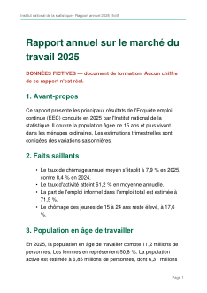

Rapport annuel sur le marché du travail…

5 pages · 2 tableau(x) · 1 page(s) scannée(s)

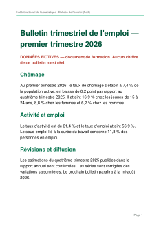

Bulletin trimestriel de l'emploi T1 2026

1 pages · 0 tableau(x)

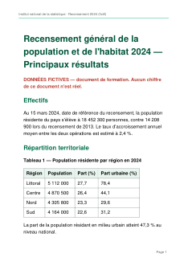

Recensement de la population 2024

2 pages · 1 tableau(x)

⚠️ Certaines pages sont **scannées** et restent invisibles pour l'assistant. Mettez `UTILISER_OCR = True` pour les lire.

```python
if ENV["name"] == "colab" and IMPORTER_PDF:
    from google.colab import files
    print("Sélectionnez un ou plusieurs PDF…")
    uploaded = BIB.folder / "uploaded"
    uploaded.mkdir(exist_ok=True)
    for name, content in files.upload().items():
        if name.lower().endswith(".pdf"):
            (uploaded / name).write_bytes(content)
    DOCUMENTS = list(DOCUMENTS) + [str(uploaded)]

if ENV["name"] == "kaggle" and Path("/kaggle/input").exists():
    found = sorted(Path("/kaggle/input").rglob("*.pdf"))
    if found:
        tableau(pd.DataFrame([{"PDF disponible": p.name, "À copier dans DOCUMENTS": f'"{p}"'} for p in found[:25]]),
                   title="PDF attachés à ce notebook Kaggle")

start = time.time()
added, errors = BIB.charger(DOCUMENTS)
cards = "".join(
    f'<div style="border:1px solid {C["sage"]};border-radius:12px;padding:10px;background:#fff;width:190px;">'
    f'{vignette_html(d.data, 1, dpi=40, width=168, caption="")}'
    f'<div style="font-weight:700;font-size:13px;margin-top:4px;">{_html.escape(d.short)}</div>'
    f'<div style="font-size:11.5px;color:{C["slate"]};">{d.pages} pages · '
    f'{sum(e.type == "table" for e in d.elements)} tableau(x)'
    + (f' · <span style="color:{C["brick"]};">{len(d.scanned_pages)} page(s) scannée(s)</span>' if d.scanned_pages else "")
    + '</div></div>' for d in BIB.documents)
display(HTML(f'{_CSS}<div class="rg"><div class="rg-title">📚 {len(BIB.documents)} document(s) chargé(s) '
             f'en {time.time() - start:.1f} s</div><div style="display:flex;gap:10px;flex-wrap:wrap;">{cards}</div></div>'))
for name, why in errors:
    encadre(f"<b>{_html.escape(name)}</b> ignoré : {_html.escape(why)}", "error")
if errors and not BIB.documents:
    encadre("Aucun document n'a pu être chargé. Si un site a refusé le téléchargement (HTTP 403), récupérez le PDF "
            "dans votre navigateur, puis mettez <code>IMPORTER_PDF = True</code> (Colab) ou indiquez le chemin du "
            "fichier dans <code>DOCUMENTS</code>.", "warning")
if any(d.scanned_pages for d in BIB.documents) and not UTILISER_OCR:
    encadre("Certaines pages sont <b>scannées</b> et restent invisibles pour l'assistant. "
            "Mettez <code>UTILISER_OCR = True</code> pour les lire.", "warning")
```

Parcours express

A2 · Préparez l’assistant

Découpage, index de recherche et calibrage automatique du seuil de confiance.

```python
start = time.time()
BIB.indexer()
model_label = f"{LLM.name} · {LLM.model}" if LLM.available else "mode extractif (sans modèle)"
display(HTML(
    f'{_CSS}<div class="rg" style="display:flex;gap:10px;flex-wrap:wrap;">'
    + "".join(f'<div style="flex:1;min-width:150px;background:#fff;border:1px solid {C["sage"]};border-radius:12px;padding:12px 16px;">'
              f'<div style="font-size:12px;color:{C["slate"]};font-weight:600;">{t}</div>'
              f'<div style="font-size:26px;font-weight:800;color:{C["dark_green"]};line-height:1.25;">{v}</div>'
              f'<div style="font-size:11.5px;color:{C["slate"]};">{s}</div></div>'
              for t, v, s in [("Documents", len(BIB.documents), f"{sum(d.pages for d in BIB.documents)} pages au total"),
                              ("Passages", len(BIB.passages), f"{len(BIB.units)} unités de recherche · {time.time() - start:.1f} s"),
                              ("Seuil de confiance", f"{BIB.threshold:.2f}", "calibré automatiquement"),
                              ("Découpage", NIVEAUX_DECOUPAGE[STRATEGIE_DECOUPAGE][0].split(" · ")[0],
                               NIVEAUX_DECOUPAGE[STRATEGIE_DECOUPAGE][0].split(" · ")[1]),
                              ("Reclassement", BIB.reranker.name.split(" · ")[0], BIB.reranker.name.split(" · ")[1]),
                              ("Rédaction", "modèle" if LLM.available else "extraits", model_label)])
    + '</div>'))
afficher_chaine()
if BIB.semantic.mode != "embeddings":
    encadre(f"Recherche sémantique : <b>{BIB.semantic.name}</b> — elle rapproche des orthographes, pas des sens. "
            "Un modèle neuronal fait le pont entre les mots de vos utilisateurs et ceux du rapport : mettez "
            "<code>INSTALLER_EMBEDDINGS = True</code> (un téléchargement d'environ 470 Mo, puis mis en cache).", "warning")
```

```
  23 passages / 59 unités de recherche indexés en 24.0 s (Embeddings · paraphrase-multilingual-MiniLM-L12-v2) · 1 sigles et 175 mots appris · calibration du seuil…
  seuil 0.39 calibré en 1.2 s
```

Documents

3

8 pages au total

Passages

23

59 unités de recherche · 25.2 s

Seuil de confiance

0.39

calibré automatiquement

Découpage

5

Deux granularités, tableaux et contexte

Reclassement

2

Couverture, densité et type de réponse

Rédaction

extraits

mode extractif (sans modèle)

🔗 La chaîne RAG, telle que configurée en ce moment

ÉTAPE 1

Question

saisie par l'utilisateur

ÉTAPE 2

Relance

réécrite en question autonome

ÉTAPE 3

Orthographe

les mots absents des documents sont corrigés

ÉTAPE 4

Normalisation

minuscules, accents, racines, mots interrogatifs retirés

ÉTAPE 5

Enrichissement

glossaire + sigles appris dans les documents

ÉTAPE 6

BM25

mots exacts, sur chaque unité de recherche

59 unités

ÉTAPE 7

Sémantique

sens, sur chaque unité de recherche

Embeddings · paraphrase-multilingual-MiniLM-L12-v2

ÉTAPE 8

Fusion

les deux classements fusionnés (RRF)

ÉTAPE 9

Reclassement

ordre décidé par le niveau que vous avez choisi

2 · Couverture, densité et type de réponse

ÉTAPE 10

Fenêtres → passages

chaque unité redonne le passage à lire

ÉTAPE 11

Garde-fous

seuil, contrôle des années, refus

seuil 0.39

ÉTAPE 12

Réponse

rédigée par le modèle, ou extraite

mode extractif

ÉTAPE 13

Vérifications

chiffres, termes manquants, filtre

Découpage : **5 · Deux granularités, tableaux et contexte** · Reclassement : **2 · Couverture, densité et type de réponse** · Passages remis à la réponse : **4**

> 💡 **Ce que signifient ces cartes.** **Documents** et **Passages** : ce qui a été lu et la façon dont cela a été découpé. **Seuil de confiance** : en dessous de ce score, l’assistant refuse de répondre (B5). **Découpage** et **Reclassement** : les deux niveaux qui décident de la qualité des réponses — la partie B les compare et vous permet de les modifier. **Rédaction** : *modèle* si un modèle de langage rédige les réponses, *extraits* en mode extractif.

> Le schéma ci-dessous est la **chaîne complète**, telle qu’elle est configurée en ce moment. La partie B4 y retrace une vraie question.

Parcours express

A3 · Poser une question

Modifiez la question entre guillemets, puis exécutez à nouveau la cellule.

```python
# 🧪 À vous : remplacez la question, puis réexécutez la cellule.
_ = demander(questions_suggerees()[0])
```

❓ Quel est le taux de chômage des femmes dans la région du Littoral ?

RÉPONSEconfiance 1.00extractivechiffres vérifiés 8/811:40:56 · 0.07 s

Tableau 2 — Taux de chômage par région en 2025 (%): Littoral — Hommes: 8,1; Femmes: 11,2; Ensemble: 9,6. Centre — Hommes: 6,4; Femmes: 8,9; Ensemble: 7,6. <sup>1</sup>

**Sources (4)**

page 3

**[1]** Rapport annuel sur le marché du travail…**5. Chômage** · p. 3 · table · confiance 1.00  
“Tableau 2 — Taux de chômage par région en 2025 (%) Littoral — Hommes: 8,1; Femmes: 11,2; Ensemble: 9,6. Centre — Hommes: 6,4; Femmes: 8,9; Ensemble: 7,6. Nord — Hommes: 5,9; Femmes: 8,0; Ensemble: 6,9. Sud — Hommes: 6,2;…”

page 2

**[2]** Rapport annuel sur le marché du travail…**5. Chômage** · p. 2 · text · confiance 0.68  
“Le chômage touche davantage les femmes (9,3 %) que les hommes (6,7 %). Il est plus élevé en milieu urbain (10,4 %) qu'en milieu rural (5,2 %). Le tableau 2 détaille le taux de chômage par région.…”

**[3]** Bulletin trimestriel de l'emploi T1 2026**Chômage** · p. 1 · text · confiance 0.44  
“Au premier trimestre 2026, le taux de chômage s'établit à 7,4 % de la population active, en baisse de 0,2 point par rapport au quatrième trimestre 2025. Il atteint 16,9 % chez les jeunes de 15 à 24 ans, 8,8 % chez les fe…”

**[4]** Rapport annuel sur le marché du travail…**7. Méthodologie** · p. 3 · text · confiance 0.36  
“L'enquête repose sur un tirage aléatoire à deux degrés. Six cents zones de dénombrement sont sélectionnées avec une probabilité proportionnelle à leur taille, puis vingt logements sont tirés dans chaque zone, soit 12 000…”

```python
# Une question de relance : l'assistant se souvient de la précédente.
_ = demander("Et pour les hommes ?" if DOCUMENTS == ["exemple"] else "Et plus en détail ?")
```

❓ Et pour les hommes ?

RÉPONSEconfiance 1.00extractivechiffres vérifiés 8/811:40:56 · 0.07 s

🧠 Compris comme : *Quel est le taux de chômage des hommes dans la région du Littoral ?* (règles)

Tableau 2 — Taux de chômage par région en 2025 (%): Littoral — Hommes: 8,1; Femmes: 11,2; Ensemble: 9,6. Centre — Hommes: 6,4; Femmes: 8,9; Ensemble: 7,6. <sup>1</sup>

**Sources (4)**

page 3

**[1]** Rapport annuel sur le marché du travail…**5. Chômage** · p. 3 · table · confiance 1.00  
“Tableau 2 — Taux de chômage par région en 2025 (%) Littoral — Hommes: 8,1; Femmes: 11,2; Ensemble: 9,6. Centre — Hommes: 6,4; Femmes: 8,9; Ensemble: 7,6. Nord — Hommes: 5,9; Femmes: 8,0; Ensemble: 6,9. Sud — Hommes: 6,2;…”

page 2

**[2]** Rapport annuel sur le marché du travail…**5. Chômage** · p. 2 · text · confiance 0.69  
“Le chômage touche davantage les femmes (9,3 %) que les hommes (6,7 %). Il est plus élevé en milieu urbain (10,4 %) qu'en milieu rural (5,2 %). Le tableau 2 détaille le taux de chômage par région.…”

**[3]** Bulletin trimestriel de l'emploi T1 2026**Chômage** · p. 1 · text · confiance 0.46  
“Au premier trimestre 2026, le taux de chômage s'établit à 7,4 % de la population active, en baisse de 0,2 point par rapport au quatrième trimestre 2025. Il atteint 16,9 % chez les jeunes de 15 à 24 ans, 8,8 % chez les fe…”

**[4]** Rapport annuel sur le marché du travail…**7. Méthodologie** · p. 3 · text · confiance 0.34  
“L'enquête repose sur un tirage aléatoire à deux degrés. Six cents zones de dénombrement sont sélectionnées avec une probabilité proportionnelle à leur taille, puis vingt logements sont tirés dans chaque zone, soit 12 000…”

> 🚀 **Parcours express : c'est terminé !** Passez maintenant à la **partie C** pour utiliser l'interface de discussion, dans le notebook ou sur le web.

PARTIE B

🔬 Parcours approfondi

Comprendre chaque brique, en observer l'effet, l'adapter à vos documents.

Parcours approfondi

B1 · Diagnostiquer les PDF

Vérifier, page par page, que le texte est réellement extractible.

Une page **scannée** ne contient qu'une image : sans OCR, l'assistant l'ignore **sans le dire**. Il répondra « information non disponible » alors que l'information figure bien dans le document. Ce diagnostic prend une seconde et évite ce piège.

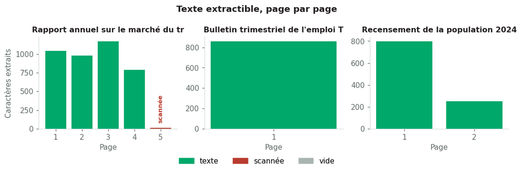

📚 Les documents de la bibliothèque

| N° | Document | Fichier | Pages | Pages scannées | Tableaux | Passages |
| --- | --- | --- | --- | --- | --- | --- |
| 0 | Rapport annuel sur le marché du travail 2025 (fictif) | rapport_emploi_2025_fictif.pdf | 5 | 5 | 2 | 14 |
| 1 | Bulletin trimestriel de l'emploi T1 2026 (fictif) | bulletin_emploi_T1_2026_fictif.pdf | 1 | — | 0 | 4 |
| 2 | Recensement de la population 2024 (fictif) | recensement_2024_fictif.pdf | 2 | — | 1 | 5 |

```python
colours = {"texte": C["green"], "scannée": C["brick"], "vide": C["grey"]}
n = len(BIB.documents)
fig, axes = plt.subplots(1, n, figsize=(max(7.5, 3.3 * n), 3.0), squeeze=False)
for ax, d in zip(axes[0], BIB.documents):
    diag = d.diagnosis
    ax.bar(diag["Page"], diag["Caractères"].clip(lower=15), color=[colours[s] for s in diag["État"]])
    for p in d.scanned_pages:
        ax.text(p, diag["Caractères"].max() * 0.08, "scannée", ha="center", rotation=90, color=C["brick"],
                fontweight="bold", fontsize=8.5)
    ax.set_title(d.short[:34], fontsize=10.5)
    pages = diag["Page"]
    ax.set_xticks(pages if len(pages) <= 20 else np.linspace(1, len(pages), 8, dtype=int))
    ax.set_xlabel("Page")
axes[0][0].set_ylabel("Caractères extraits")
from matplotlib.patches import Patch
fig.legend(handles=[Patch(color=v, label=k) for k, v in colours.items()], loc="lower center", ncol=3,
           bbox_to_anchor=(0.5, -0.08))
fig.suptitle("Texte extractible, page par page", fontweight="bold", color=C["ink"])
plt.tight_layout()
fig.savefig(DOSSIER_SORTIE / "diagnostic_pages.png", dpi=160, bbox_inches="tight")
plt.show()
tableau(BIB.resume(), title="📚 Les documents de la bibliothèque")
```

Parcours approfondi

B2 · Extraire la structure

Titres, en-têtes répétés, mots coupés, tableaux et OCR.

| Opération | Principe | Pourquoi |
| --- | --- | --- |
| **Détecter les titres** | Une ligne écrite nettement plus grande que le corps du texte | Chaque passage connaît sa **section** |
| **Supprimer les en-têtes et pieds de page** | Une ligne répétée en haut ou en bas d'au moins la moitié des pages | « Page 3 » pollue chaque passage |
| **Recoller les mots coupés** | « statis-⏎tiques » → « statistiques » | La recherche retrouve le mot entier |
| **Linéariser les tableaux** | Chaque ligne devient « Libellé — colonne : valeur ; … » | Un nombre isolé ne veut rien dire |
| **OCR** (facultatif) | Reconnaissance de texte sur les pages scannées | Rend visibles les pages scannées |

La normalisation **NFKC** remplace aussi les ligatures typographiques (« ﬁ », « ﬀ ») par des lettres ordinaires : sans elle, « ﬁche » ne correspondrait jamais à « fiche ».